# PSC mice P76_3

- Show All Code
- Hide All Code
- View Source

Rnaseq dataset part3

# 1 Introduction

This report presents a preliminary transcriptomic analysis of liver samples from a PSC mouse model (experiment P76_3), asking how diet and sex jointly shape hepatic gene expression.

RNA-seq data was processed using custom bioinformatic pipeline available at https://github.com/xpolak37/RNAseq_workflow.

Data from 44 animals (SD: 10F/11M; GFD: 11F/12M) were modeled in DESeq2 using the design Date + Diet + Sex + Diet:Sex, with SD and female as reference levels; the Diet×Sex interaction is the primary term of interest, since it tests whether diet acts differently in the two sexes rather than assuming a single “overall” diet effect.

After keeping genes detected (non-zero count) in at least 5 samples of at least one Diet × Sex group, 25981 genes were retained (section 3.1).

This part covers the integration of liver expression with serum bile acids (A8) and clinical liver markers (B2), and pathway enrichment (Hallmark, KEGG, Reactome). Global structure, differential expression and the gene panels are described in part 2.

One caveat runs through the whole analysis: the four groups were collected in blocks (SD_F first, GFD_M last; see part 2, A3), so collection order, which carries time-of-day and feeding-state information, is strongly confounded with group.

**Open code**

```r
source("custom_functions_rnaseq.R")
```

# 2 Import

Two inputs are loaded:

- **Gene-level expression** (`tpm_data.tsv`): TPM values per gene and sample, produced by the RNA-seq pipeline.
- **Sample metadata** (`metadata_P076v3.xlsx`): one row per animal with diet, sex, collection date/order and other annotations. Rows without an RNA-seq sample ID (`SampleIAB`) are dropped, a combined `Group` label (e.g. `GFD_M`) is created from Diet and Sex, and `SampleID` is set to the RNA-seq sample ID so that metadata rows can be matched to expression data.

**Open code**

```r
# load gene level data
gene_df <- fread("../../Data/tpm_data.tsv") %>% as.data.frame()

# load metadata
sample_metadata <- read.xlsx("../../Data/metadata_P076v3.xlsx",detectDates = TRUE) %>%
  dplyr::filter(!is.na(SampleIAB)) %>%
  dplyr::mutate(Group=paste(Diet,Sex,sep = "_")) %>%
  dplyr::mutate(SampleID=SampleIAB)
```

**Open code**

```r
# assign colors to groups
group_colours <- c("GFD_F"="#e59866",
                   "GFD_M"= "#7fb3d5",
                   "SD_F"="#b03a2e",
                  "SD_M"="#1c4c78")
```

# 3 Analysis

This part repeats the data preparation from part 2 so that it can run on its own. The transcript import itself was run in part 2 and saved; it is loaded here.

- `tx2gene` is a transcript-to-gene lookup (`tx2gene.tsv`) built from the same Ensembl GRCm39 annotation that was used for the Salmon index, including gene symbols.
- `tximport()` reads the Salmon quantification of every sample and sums transcript-level estimates into gene-level estimated counts, keeping average transcript lengths for DESeq2 to use as a correction. Transcript version suffixes (e.g. `.3`) are ignored so that IDs match the annotation.

**Load dataset**

The saved import is loaded, and the metadata variables are converted to factors with explicit reference levels: **SD** for Diet and **F** for Sex. Collection date is also converted to a factor. The DESeq2 object is then built with the design `~ Date + Diet * Sex`, which expands to Date + Diet + Sex + Diet:Sex.

**Open code**

```r
load("../Results/transcript_import.RData")

# metadata to factors
sample_metadata <- sample_metadata %>%
  mutate(
    Diet  = factor(Diet, levels = c("SD", "GFD")),
    Sex   = factor(Sex,  levels = c("F", "M")),
    Group = factor(paste(Diet, Sex, sep = "_")),
    Date = factor(gsub("-","_",Date))
  )

# Build DESeq2 object (factorial design)
dds <- DESeqDataSetFromTximport(
  txi,
  colData = sample_metadata,
  design  = ~ Date + Diet * Sex            # = Diet + Sex + Diet:Sex
)
```

```
using counts and average transcript lengths from tximport
```

## 3.1 Filter

Genes that are barely detected are removed. A gene is kept if it has a non-zero count in at least 5 samples of at least one group (SD_F, SD_M, GFD_F or GFD_M), so genes switched on in only one condition are retained.

**Open code**

```r
# genes detected (count > 0) in >= 5 samples of at least one group
min_count <- 5
grp <- sample_metadata$Group
keep <- sapply(levels(factor(grp)), function(g) {
  rowSums(counts(dds)[, grp == g, drop = FALSE] > 0) >= min_count
})
keep <- rowSums(keep) >= 1   # passes in at least one group
dds  <- dds[keep, ]

cat(sum(keep), "genes kept after filtering\n")
```

```
25981 genes kept after filtering
```

## 3.2 Run Deseq

Design: Date + Diet + Sex + Diet:Sex.

Reference factors: Diet: SD Sex: F

The full model is:

**Date** - a covariate we’re adjusting for (collection date) **Diet** - main effect of diet (Effect of diet on reference SEX=F) **Sex** - main effect of sex (Effect of sex on reference Diet=SD) **Diet:Sex** - the interaction: whether diet’s effect on expression differs between sexes (or equivalently, whether the sex difference depends on diet). This is usually the term we care about.

**Open code**

```r
dds <- DESeq(dds)
```

```
using 'avgTxLength' from assays(dds), correcting for library size
```

```
-- replacing outliers and refitting for 13 genes
-- DESeq argument 'minReplicatesForReplace' = 7
-- original counts are preserved in counts(dds)
```

**Open code**

```r
vsd <- vst(dds, blind = FALSE)
m  <- assay(vsd)  # genes x samples
cd <- as.data.frame(colData(dds))
cd$Order <- as.numeric(cd$Order)
```

## 3.3 Date + Diet * Sex

**GFD vs SD (diet effect)**

- **IN FEMALES** - the diet effect in females is captured entirely by the main-effect coefficient, because females are the reference (single coef is enough)
- **IN MALES**- there’s no single coefficient for “diet effect in males.” We have to build it by adding the female diet effect plus the male-specific adjustment:

DietGFD.SexM = (DIET_MALES) - (DIET_FEMALES), so then:

DIET_MALES = DIET_FEMALES + DietGFD.SexM

**M vs F (Sex effect)**

- **IN SD** - we have it already in the model: Sex_M_vs_F is effect of sex in reference diet (SD)
- **IN GFD**- SEX_GFD = SEX_SD + DietGFD.SexM

**Open code**

```r
alpha <- 0.05
lfc   <- 1

# ashr: it shrinks single coefficients AND summed contrasts

# GFD vs SD (diet effect)
## in females
res_diet_in_F  <- lfcShrink(dds, coef = "Diet_GFD_vs_SD", type = "ashr")
```

```
using 'ashr' for LFC shrinkage. If used in published research, please cite:
    Stephens, M. (2016) False discovery rates: a new deal. Biostatistics, 18:2.
    https://doi.org/10.1093/biostatistics/kxw041
```

**Open code**

```r
## in males
res_diet_in_M  <- lfcShrink(
  dds, contrast = list(c("Diet_GFD_vs_SD","DietGFD.SexM")),
  type = "ashr")
```

```
using 'ashr' for LFC shrinkage. If used in published research, please cite:
    Stephens, M. (2016) False discovery rates: a new deal. Biostatistics, 18:2.
    https://doi.org/10.1093/biostatistics/kxw041
```

**Open code**

```r
# M vs F (sex effect)

## IN SD
res_sex_in_SD  <- lfcShrink(dds, coef = "Sex_M_vs_F", type = "ashr")
```

```
using 'ashr' for LFC shrinkage. If used in published research, please cite:
    Stephens, M. (2016) False discovery rates: a new deal. Biostatistics, 18:2.
    https://doi.org/10.1093/biostatistics/kxw041
```

**Open code**

```r
## IN GFD
res_sex_in_GFD <- lfcShrink(
  dds, contrast = list(c("Sex_M_vs_F","DietGFD.SexM")),
  type = "ashr")
```

```
using 'ashr' for LFC shrinkage. If used in published research, please cite:
    Stephens, M. (2016) False discovery rates: a new deal. Biostatistics, 18:2.
    https://doi.org/10.1093/biostatistics/kxw041
```

**Open code**

```r
# Interaction: does the diet effect depend on sex?
res_int <- lfcShrink(dds, coef = "DietGFD.SexM", type = "ashr")
```

```
using 'ashr' for LFC shrinkage. If used in published research, please cite:
    Stephens, M. (2016) False discovery rates: a new deal. Biostatistics, 18:2.
    https://doi.org/10.1093/biostatistics/kxw041
```

**Open code**

```r
# Summarise significant-gene counts
summarise_res <- function(res, sym,name) {
  sig <- subset(as.data.frame(res),
                !is.na(padj) & padj < alpha & abs(log2FoldChange) >= lfc)
  message(sprintf("%-24s : %d significant genes", name, nrow(sig)))
  sig <- sig %>%
  rownames_to_column("gene_id") %>%     # name the key column correctly
  left_join(sym, by = "gene_id")

  write.xlsx(sig,paste0("../Results/",name,".xlsx"),rownames=FALSE)
  return(sig)
}

# keeps only the columns we pick and collapses the result to unique combinations, throwing away the transcript-level duplication.
sym <- distinct(tx2gene, gene_id, gene_name)   # lookup

# summary
sig_diet_F  <- summarise_res(res_diet_in_F,sym,  "Diet effect in females")
```

```
Diet effect in females   : 3 significant genes
```

**Open code**

```r
sig_diet_M  <- summarise_res(res_diet_in_M,sym,  "Diet effect in males")
```

```
Diet effect in males     : 1286 significant genes
```

**Open code**

```r
sig_sex_SD  <- summarise_res(res_sex_in_SD,sym,  "Sex effect in SD")
```

```
Sex effect in SD         : 564 significant genes
```

**Open code**

```r
sig_sex_GFD <- summarise_res(res_sex_in_GFD,sym, "Sex effect in GFD")
```

```
Sex effect in GFD        : 6129 significant genes
```

**Open code**

```r
sig_int     <- summarise_res(res_int,sym,        "Diet x Sex interaction")
```

```
Diet x Sex interaction   : 75 significant genes
```

# 4 Building panels

Each gene is **z-scored** across samples (centered to mean 0 and scaled to standard deviation 1), so that genes with different expression levels contribute equally when they are averaged into a panel score. `z` is the resulting matrix.

**Open code**

```r
vsd <- vst(dds, blind = FALSE)
m  <- assay(vsd)  # genes x samples
z <- t(scale(t(m)))
```

The gene panels are defined by gene symbol, exactly as in part 2:

- All genes of the major urinary protein family (`Mup1`, `Mup2`, …), a classic male-biased liver program, are added to the male-liver panel.
- Symbols are mapped to Ensembl gene IDs (`sym2id`).
- A **coverage table** reports, for each panel, how many requested genes are present, which symbols were not found in the annotation, and which were removed by the low-count filter; a case-insensitive search suggests matches for symbols that were not found.
- `panels` is the final list of gene IDs per panel.

**Open code**

```r
panels_sym <- list(
  `1a_male_liver`   = c("Hsd3b5","Cyp4a12a","Cyp4a12b","Cyp2d9","Cyp7b1","Slco1a1",
                        "Elovl3","Nudt7","Ugt2b1","Bcl6"),
  `1b_female_liver` = c("Cyp2b9","Cyp3a41a","Cyp3a44","Cyp2a4","Sult3a1","Sult2a1",
                        "Fmo3","A1bg","Nnmt","Cux2"),
  `1c_GH_STAT5`     = c("Ghr","Stat5b","Socs2","Cish","Igf1","Igfals","Socs3"),
  `2_IEG_stress`    = c("Fos","Fosb","Jun","Junb","Jund","Egr1","Atf3","Dusp1",
                        "Nr4a1","Hspa1a","Hspa1b"),
  `3a_GC_targets`   = c("Tsc22d3","Fkbp5","Klf15","Sds","Zbtb16","Per1"),
  `3b_fasting`      = c("Fgf21","Hmgcs2","Cpt1a","Ppargc1a","Pck1","G6pc1",
                        "Angptl4","Slc25a20"),
  `3c_lipogenesis`  = c("Fasn","Scd1","Elovl6","Acaca","Srebf1","Mlxipl","Hmgcs1",
                        "Hmgcr","Sqle","Ldlr","Insig1"),
  `4_circadian`     = c("Bmal1","Npas2","Nr1d1","Nr1d2","Per1","Per2","Per3","Cry1",
                        "Cry2","Dbp","Tef","Hlf","Nfil3","Ciart"),
  `5_fibrosis`      = c("Col1a1","Col1a2","Col3a1","Acta2","Timp1","Timp2","Lox",
                        "Pdgfrb","Tgfb1","Sparc"),
  `6_ductular`      = c("Krt19","Krt7","Epcam","Sox9","Spp1","Cldn7","Hnf1b"),
  `7_inflammation`  = c("Ccl2","Ccl5","Cxcl1","Cxcl9","Tnf","Il1b","Il6","Lcn2",
                        "Saa1","Saa2","Adgre1","Itgam","Mmp12"),
  `8_cholestasis`   = c("Cyp7a1","Cyp8b1","Cyp27a1","Cyp2c70","Cyp2a12","Nr0b2",
                        "Nr1h4","Slc10a1","Abcb11","Abcc3","Abcc4","Slc51a","Slc51b",
                        "Baat","Abcb4")
)

# "Mup family "
mup_syms <- grep("^Mup[0-9]", sym$gene_name, value = TRUE) %>% unique()
panels_sym[["1a_male_liver"]] <- c(panels_sym[["1a_male_liver"]], mup_syms)
cat("Mup family notation found in :", length(mup_syms), "genes\n")
```

```
Mup family notation found in : 22 genes
```

**Open code**

```r
# map with gene id and gene name
sym2id <- function(s) sym$gene_id[match(s, sym$gene_name)]

# QC / coverage-check step: for each gene panel
# it counts how many of requested genes actually made it into expression data,
# and reports which genes dropped out and why.
coverage <- lapply(names(panels_sym), function(nm) {
  s  <- panels_sym[[nm]]
  id <- sym2id(s)
  in_annot <- !is.na(id)
  in_data  <- in_annot & id %in% rownames(m)
  data.frame(
    panel             = nm,
    requested         = length(s),
    in_data           = sum(in_data),
    not_in_annotation = paste(s[!in_annot],            collapse = ", "),
    filtered_lowcount = paste(s[in_annot & !in_data],  collapse = ", ")
  )
}) %>% dplyr::bind_rows()

coverage %>%
  kable(
    caption = "Genes detected in our RNAseq dataset",
    digits  = 8,
    booktabs = TRUE,
    align = "llcccccc"
  ) %>%
  kable_styling(
    latex_options = c("hold_position"),
    bootstrap_options = c("striped", "hover", "condensed")
  )
```

Genes detected in our RNAseq dataset

| panel | requested | in_data | not_in_annotation | filtered_lowcount |
| --- | --- | --- | --- | --- |
| 1a_male_liver | 32 | 32 |  |  |
| 1b_female_liver | 10 | 10 |  |  |
| 1c_GH_STAT5 | 7 | 7 |  |  |
| 2_IEG_stress | 11 | 11 |  |  |
| 3a_GC_targets | 6 | 6 |  |  |
| 3b_fasting | 8 | 8 |  |  |
| 3c_lipogenesis | 11 | 11 |  |  |
| 4_circadian | 14 | 14 |  |  |
| 5_fibrosis | 10 | 10 |  |  |
| 6_ductular | 7 | 7 |  |  |
| 7_inflammation | 13 | 13 |  |  |
| 8_cholestasis | 15 | 15 |  |  |

**Open code**

```r
# case-insensitive
missing_all <- unique(unlist(lapply(panels_sym, function(s) s[is.na(sym2id(s))])))
if (length(missing_all)) {
  cat("\ncase-insensitive:\n")
  for (g in missing_all) {
    hit <- grep(paste0("^", g, "$"), sym$gene_name, ignore.case = TRUE, value = TRUE)
    if (length(hit)) cat(sprintf("  %-12s -> %s\n", g, paste(hit, collapse = ", ")))
  }
}

# final panels
panels <- lapply(panels_sym, function(s) {
  id <- sym2id(s); unique(id[!is.na(id) & id %in% rownames(m)])
})
```

The sex-specific liver program scores from part 2 (A4) are recomputed here because they are used in the phenotype analysis (B2). Each score is the mean z-score of the panel’s genes in a sample; the **masculinization index** is the male-liver score minus the female-liver score (higher = more male-like liver).

**Open code**

```r
program_panels <- c("1a_male_liver", "1b_female_liver", "1c_GH_STAT5")

# score = mean z-score of gene panels for each samples
scores <- sapply(program_panels, function(nm) {
   colMeans(z[panels[[nm]], , drop = FALSE], na.rm = TRUE)
})

colnames(scores) <- program_panels


# masculinization index:
# male-female program (1 axis, direct feminization test)
scores <- cbind(scores,
                masc_index = scores[, "1a_male_liver"] - scores[, "1b_female_liver"])
```

# 5 A8: Bile acids

This section links liver gene expression to serum bile-acid measurements from the same animals.

The chunk below loads the bile-acid table, keeps the animals present in the RNA-seq data, harmonizes the diet label (`STD` → `SD`), and reorders the rows to match the sample metadata.

**Open code**

```r
bile_acids <- read.xlsx("../../Docs/bile acids_76.xlsx") %>%
  dplyr::filter(ID %in% sample_metadata$MID) %>%
  dplyr::mutate(MID=ID,
                Diet=ifelse(diet=="STD","SD",diet))

# check
bile_acids <- bile_acids %>% column_to_rownames("MID")
bile_acids <- bile_acids[as.character(sample_metadata$MID),]
all(bile_acids$sex == sample_metadata$Sex)
```

```
[1] TRUE
```

**Open code**

```r
all(bile_acids$Diet == sample_metadata$Diet)
```

```
[1] TRUE
```

**Open code**

```r
bile_acids <- bile_acids %>% rownames_to_column("MID") %>%
  dplyr::select(MID,CA:gLCA)
```

**Calculations**:

- **total_pool**: the sum of seven measured species (tCA, taMCA, tbMCA, CA, aMCA, bMCA, LCA). It is not the full bile-acid pool: other species in the table (e.g. DCA, CDCA, UDCA, ωMCA and their conjugates) are not included. It pairs with Cyp7a1, the enzyme catalyzing the rate-limiting first step of bile-acid synthesis, so higher Cyp7a1 would be expected to go with a larger pool.
- **index_12a**: a 12α-hydroxylation index, tCA / (taMCA + tbMCA). Cyp8b1 adds the 12α-hydroxyl group that turns the bile-acid precursor into cholic acid instead of muricholic acids, so a **positive** correlation between liver Cyp8b1 mRNA and this serum ratio would indicate that the two layers agree. The index is a simplified proxy: it uses only taurine-conjugated CA and leaves out unconjugated CA and DCA (also 12α-hydroxylated). Animals with tCA = 0 (probably below the detection limit) get an index of exactly 0.

**Open code**

```r
## derived quantities
bile_acids <- bile_acids %>%
  mutate(
    total_pool = rowSums(across(c(tCA, taMCA, tbMCA, CA, aMCA, bMCA, LCA)),
                         na.rm = TRUE),
    index_12a  = tCA / (taMCA + tbMCA),          # 12α index
    muricholic = taMCA + tbMCA                    # for Cyp2c70
  )

## pull the enzyme genes from VST matrix (m), keyed to samples
enzyme_syms <- c("Cyp8b1", "Cyp7a1", "Cyp2c70")
enzyme_ids  <- sym$gene_id[match(enzyme_syms, sym$gene_name)]

names(enzyme_ids) <- enzyme_syms
all(enzyme_ids %in% rownames(m))
```

```
[1] TRUE
```

**Open code**

```r
enzyme_expr <- t(m[enzyme_ids, , drop = FALSE])
colnames(enzyme_expr) <- enzyme_syms
enzyme_df <- as.data.frame(enzyme_expr) %>%
  rownames_to_column("SampleIAB")

## join expression + serum + group (inner join keeps the 44 matched animals)
dat <- cd %>%
  dplyr::select(SampleIAB, MID, Group, Diet, Sex) %>%
  dplyr::mutate(MID = as.character(MID)) %>%          # double -> character
  inner_join(enzyme_df, by = "SampleIAB") %>%
  inner_join(bile_acids %>% dplyr::mutate(MID = as.character(MID)),
             by = "MID")

cat("Animals with both layers:", nrow(dat), "\n")
```

```
Animals with both layers: 44
```

### 5.0.1 Correlations

Each enzyme is correlated with its matching bile-acid readout using Spearman’s rank correlation, which is robust to outliers and does not assume a linear relationship. Two versions are computed:

- **Overall**: across all animals. This can be driven by differences between groups (e.g. if one group is high in both).
- **Within-group**: each variable is first centered within its group (the group mean is subtracted), and the centered values are correlated. This removes group differences and asks whether animals that are higher than their group average in one layer are also higher in the other. A within-group correlation is stronger evidence of a genuine per-animal link.

**Open code**

```r
#  ENZYME-METABOLITE Spearman correlations across all animals and within-group

# helper: within-group centering (subtract each group's mean)
center_within <- function(x, grp) x - ave(x, grp, FUN = function(v) mean(v, na.rm = TRUE))

cor_pair <- function(dat, expr_col, metab_col, label) {
  x <- dat[[expr_col]]; y <- dat[[metab_col]]; g <- dat$Group
  ok <- is.finite(x) & is.finite(y)

  # overall
  ov <- suppressWarnings(cor.test(x[ok], y[ok], method = "spearman"))

  # within-group: center both, then correlate
  xc <- center_within(x, g); yc <- center_within(y, g)
  ok2 <- is.finite(xc) & is.finite(yc)
  wi <- suppressWarnings(cor.test(xc[ok2], yc[ok2], method = "spearman"))

  data.frame(
    pair          = label,
    rho_overall   = unname(ov$estimate), p_overall   = ov$p.value,
    rho_within    = unname(wi$estimate), p_within    = wi$p.value,
    n             = sum(ok)
  )
}

cor_tab <- bind_rows(
  cor_pair(dat, "Cyp8b1",  "index_12a",  "Cyp8b1 ~ 12a-index"), # main
  cor_pair(dat, "Cyp7a1",  "total_pool", "Cyp7a1 ~ total pool"),# supplementary
  cor_pair(dat, "Cyp2c70", "muricholic", "Cyp2c70 ~ taMCA+tbMCA"),
  cor_pair(dat, "Cyp8b1", "muricholic", "Cyp8b1 ~ taMCA+tbMCA")
)

cor_tab %>% kable(
    caption = "Correlations",
    digits  = 8,
    booktabs = TRUE,
    align = "llcccccc"
  ) %>%
  kable_styling(
    latex_options = c("hold_position"),
    bootstrap_options = c("striped", "hover", "condensed")
  )
```

Correlations

| pair | rho_overall | p_overall | rho_within | p_within | n |
| --- | --- | --- | --- | --- | --- |
| Cyp8b1 ~ 12a-index | -0.5636109 | 0.00006786 | -0.4344731 | 0.00320973 | 44 |
| Cyp7a1 ~ total pool | -0.2345314 | 0.12526622 | -0.1361522 | 0.37693831 | 44 |
| Cyp2c70 ~ taMCA+tbMCA | 0.3550388 | 0.01852965 | 0.2050740 | 0.18120625 | 44 |
| Cyp8b1 ~ taMCA+tbMCA | -0.3936575 | 0.00860397 | -0.1821001 | 0.23594695 | 44 |

**Open code**

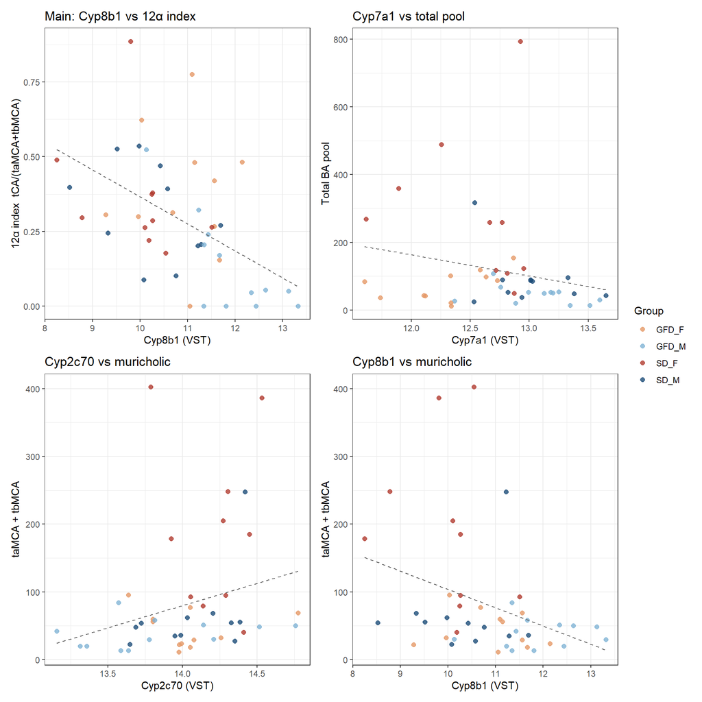

```r
# SCATTER plots, coloured by group
scatter_pair <- function(dat, expr_col, metab_col, xlab, ylab, ttl) {
  ggplot(dat, aes(.data[[expr_col]], .data[[metab_col]], colour = Group)) +
    geom_point(size = 2, alpha = 0.8) +
    geom_smooth(method = "lm", se = FALSE, colour = "grey40",
                linewidth = 0.5, linetype = "dashed") +   # overall trend
    labs(x = xlab, y = ylab, title = ttl) +
    theme_bw() +
    scale_color_manual(values=group_colours)
}

p_main <- scatter_pair(dat, "Cyp8b1", "index_12a",
                       "Cyp8b1 (VST)", "12α index  tCA/(taMCA+tbMCA)",
                       "Main: Cyp8b1 vs 12α index")
p_s1   <- scatter_pair(dat, "Cyp7a1", "total_pool",
                       "Cyp7a1 (VST)", "Total BA pool", "Cyp7a1 vs total pool")
p_s2   <- scatter_pair(dat, "Cyp2c70", "muricholic",
                       "Cyp2c70 (VST)", "taMCA + tbMCA", "Cyp2c70 vs muricholic")
p_s3   <- scatter_pair(dat, "Cyp8b1", "muricholic",
                       "Cyp8b1 (VST)", "taMCA + tbMCA", "Cyp8b1 vs muricholic")

((p_main | p_s1) / (p_s2 | p_s3)) + plot_layout(guides = "collect")
```

**Open code**

```r
# helpers for inline numbers
cv <- function(pair, col, d = 2) signif(cor_tab[cor_tab$pair == pair, col], d)

# animals at the detection floor (tCA = 0 -> index_12a = 0)
n_zero    <- sum(dat$index_12a == 0, na.rm = TRUE)
n_zero_gm <- sum(dat$index_12a == 0 & dat$Group == "GFD_M", na.rm = TRUE)

# sensitivity: Cyp8b1 ~ 12a-index without the zero-index animals
nz      <- is.finite(dat$index_12a) & dat$index_12a > 0
cor_nz  <- suppressWarnings(cor.test(dat$Cyp8b1[nz], dat$index_12a[nz], method = "spearman"))
cor_nz
```

```
    Spearman's rank correlation rho

data:  dat$Cyp8b1[nz] and dat$index_12a[nz]
S = 14650, p-value = 0.002082
alternative hypothesis: true rho is not equal to 0
sample estimates:
       rho
-0.4827935
```

**Open code**

```r
# group means of Cyp8b1 and the 12a-index
grp_ba <- aggregate(cbind(Cyp8b1, index_12a) ~ Group, data = dat, FUN = mean)
grp_ba
```

```
  Group    Cyp8b1 index_12a
1 GFD_F 10.924066 0.3746417
2 GFD_M 11.900959 0.1343035
3  SD_F  9.993432 0.3638211
4  SD_M 10.305997 0.3124575
```

**NoteInterpretation**

**Cyp8b1 vs 12α-index.** The correlation is **negative** (overall rho = -0.56, p = 6.8^{-5}; within-group rho = -0.43, p = 0.0032). This is the opposite of the direct enzyme–product relationship described above, so it does not confirm it. Two explanations are plausible:

- **Feedback:** low serum CA means weaker FXR activation, which releases the repression of Cyp8b1.
- **Detection floor:** 5 animals (4 of them GFD males) have a 12α-index of exactly 0, and they sit at high Cyp8b1. Without them, rho = -0.48 (p = 0.0021).

**Cyp7a1 vs total pool.** No significant correlation (rho = -0.23, p = 0.13), so the expected link is not seen in these data.

**Cyp2c70 and Cyp8b1 vs muricholic acids.** Both overall correlations are significant (Cyp2c70 rho = 0.36, Cyp8b1 rho = -0.39) but neither holds within groups (p = 0.18 and 0.24), so they reflect differences between groups rather than a per-animal link.

### 5.0.2 PCA

Are GFD males outliers in the narrow BA-metabolism panel, independently of the global (thousands-of-genes) structure?

A PCA is run on the cholestasis/bile-acid panel (panel 8) alone, using all of its 15 genes; none of them belong to the sex-specific liver panels. The panel genes are z-scored across samples; since they are already centered and scaled, `prcomp()` is run without further centering or scaling. The plot shows each animal on PC1 and PC2 of this small gene set, with an ellipse per group summarizing where most of the group’s animals lie.

**Open code**

```r
# PCA on PANEL 8 ONLY
panel8_ids <- intersect(panels[["8_cholestasis"]], rownames(m))   # present only

cat("Panel-8 genes used:", length(panel8_ids), "\n")
```

```
Panel-8 genes used: 15
```

**Open code**

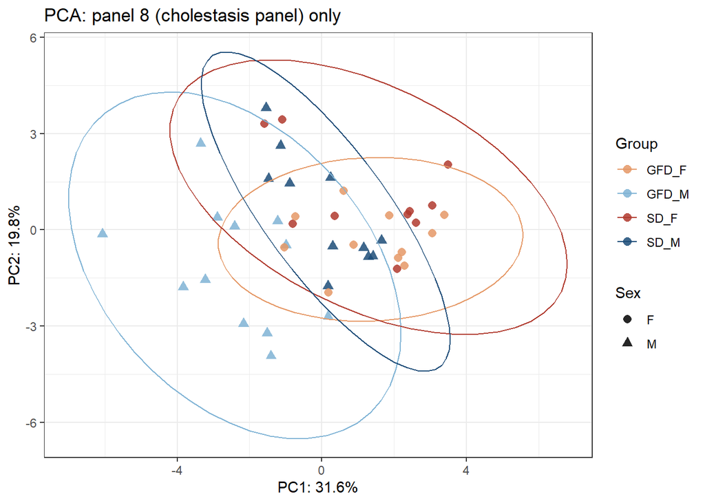

```r
## panel-8 expression matrix, genes z-scored across samples
m8 <- m[panel8_ids, , drop = FALSE]
z8 <- t(scale(t(m8)))
z8 <- z8[, cd$SampleIAB, drop = FALSE]

##PCA on panel 8
pca8 <- prcomp(t(z8), center = FALSE, scale. = FALSE)
pv8  <- round(100 * pca8$sdev^2 / sum(pca8$sdev^2), 1)

pca8_df <- as.data.frame(pca8$x[, 1:2]) %>%
  mutate(Group = cd$Group,
         Sex = cd$Sex,
         Diet = cd$Diet)

p_pca8 <- ggplot(pca8_df,
                 aes(PC1, PC2, colour = Group, shape = Sex)) +
  geom_point(size = 2.5, alpha = 0.85) +
  stat_ellipse(aes(group = Group), type = "norm", linewidth = 0.4) +
  labs(x = paste0("PC1: ", pv8[1], "%"), y = paste0("PC2: ", pv8[2], "%"),
       title = "PCA: panel 8 (cholestasis panel) only") +
  theme_bw() +
  scale_color_manual(values = group_colours)

p_pca8
```

## 5.1 PERMANOVA

**Open code**

```r
# same scale as the PCA above: z-scored panel-8 genes
mat   <- z8 %>% t()
cd <- as.data.frame(colData(dds))

# align metadata to the expression matrix
meta  <- cd[match(rownames(mat), cd$SampleIAB), ]
nrow(meta) == nrow(mat)
```

```
[1] TRUE
```

**Open code**

```r
d <- dist(mat) # Euclidean on z-scored VST

# Dispersion homogeneity
bd <- betadisper(d, meta$Group)

# if significant -> groups differ in SPREAD, PERMANOVA may be  invalid
anova(bd) %>% kable(
    caption = "Results for test of dispersion homogeneity",
    digits  = 8,
    booktabs = TRUE,
    align = "llcccccc"
  ) %>%
  kable_styling(
    latex_options = c("hold_position"),
    bootstrap_options = c("striped", "hover", "condensed")
  )
```

Results for test of dispersion homogeneity

|  | Df | Sum Sq | Mean Sq | F value | Pr(>F) |
| --- | --- | --- | --- | --- | --- |
| Groups | 3 | 4.325596 | 1.441865 | 1.439042 | 0.2457207 |
| Residuals | 40 | 40.078479 | 1.001962 | NA | NA |

**Open code**

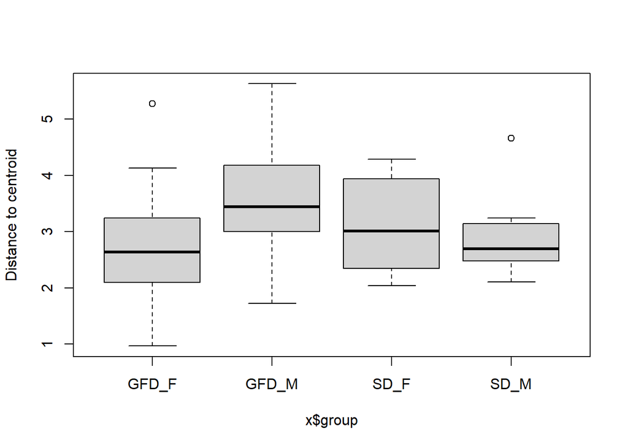

```r
boxplot(bd)             # visualize per-group spread
```

**Open code**

```r
set.seed(123)
pmv8 <- adonis2(d ~ Diet * Sex,
               data = meta,
               strata = meta$Date,
               by = "terms", # sequential; tests each term in order
               permutations = 9999)

pmv8 %>%    kable(
    caption = "PERMANOVA result (panel 8, date-stratified)",
    digits  = 8,
    booktabs = TRUE,
    align = "llcccccc"
  ) %>%
  kable_styling(
    latex_options = c("hold_position"),
    bootstrap_options = c("striped", "hover", "condensed")
  )
```

PERMANOVA result (panel 8, date-stratified)

|  | Df | SumOfSqs | R2 | F | Pr(>F) |
| --- | --- | --- | --- | --- | --- |
| Diet | 1 | 66.69406 | 0.1034016 | 5.813272 | 0.0001 |
| Sex | 1 | 98.11994 | 0.1521239 | 8.552455 | 0.0001 |
| Diet:Sex | 1 | 21.27713 | 0.0329878 | 1.854584 | 0.0714 |
| Residual | 40 | 458.90887 | 0.7114866 | NA | NA |
| Total | 43 | 645.00000 | 1.0000000 | NA | NA |

**NoteInterpretation**

On the bile-acid panel alone, Sex (R² = 15%, p = 10^{-4}) and Diet (R² = 10%, p = 10^{-4}) both shift the profile, and the Diet×Sex interaction is small (R² = 3.3%, p = 0.0714). In the PCA, GFD males are **shifted** along PC1 but their ellipse still overlaps the SD groups, so they are displaced rather than fully separated.

**Open code**

```r
save(pmv8,p_pca8,file = "../Results/figures/FS5.RData")
```

# 6 B2: Phenotype

**Clinical liver-function markers**

This section asks whether the transcriptomic results relate to clinical and physiological readouts.

The chunk below loads the clinical parameters (serum liver markers and other measurements) and merges them with a freshly re-read copy of the sample metadata.

**Open code**

```r
params <- read.xlsx("../../Data/P076_3_params.xlsx") %>%
  dplyr::filter(MID %in% sample_metadata$MID)

# load metadata
sample_metadata <- read.xlsx("../../Data/metadata_P076v3.xlsx",detectDates = TRUE) %>%
  dplyr::filter(!is.na(SampleIAB)) %>%
  dplyr::mutate(Group=paste(Diet,Sex,sep = "_")) %>%
  dplyr::mutate(SampleID=SampleIAB)

sample_metadata <- merge(sample_metadata,params,by="MID",all=TRUE)

# merge() renames Date to Date.x if the params table also has a Date column
if (!"Date" %in% names(sample_metadata) && "Date.x" %in% names(sample_metadata))
  sample_metadata$Date <- sample_metadata$Date.x

# same reference levels as the rest of the report (SD, F)
sample_metadata <- sample_metadata %>%
  mutate(Diet = factor(Diet, levels = c("SD", "GFD")),
         Sex  = factor(Sex,  levels = c("F", "M")),
         Date = factor(gsub("-", "_", Date)))
```

A PCA of the whole transcriptome is recomputed (the 2,000 most variable genes on the VST scale) to obtain each animal’s PC1 and PC2 coordinates. These are merged in one table (`pc_full`) with:

- the bile-acid quantities (from A8),
- the clinical parameters.

**Open code**

```r
## Get PC1/PC2 per animal from the global VST PCA
vsd_mat <- assay(vsd)                       # or m

rv    <- matrixStats::rowVars(vsd_mat)
top   <- order(rv, decreasing = TRUE)[seq_len(min(2000, length(rv)))]
pca   <- prcomp(t(vsd_mat[top, ]), scale. = FALSE)
pv    <- round(100 * pca$sdev^2 / sum(pca$sdev^2), 1)

pc_df <- as.data.frame(pca$x[, 1:2]) %>%
  rownames_to_column("SampleIAB") %>%
  left_join(cd %>% as.data.frame() %>%
              dplyr::select(SampleIAB, MID, Group, Diet, Sex),
            by = "SampleIAB")

# phenotype table
pheno <- sample_metadata

# bile-acid derived indices from A8 (dat has SampleIAB + MID + indices)
ba_df <- dat %>%
  dplyr::select(SampleIAB, MID, total_pool, index_12a, muricholic)

## merge everything onto the PC table
pc_full <- pc_df %>% dplyr::select(-Diet,-Sex) %>%
  mutate(MID = as.character(MID)) %>%
  left_join(ba_df %>% mutate(MID = as.character(MID)) %>%
              dplyr::select(-SampleIAB), by = "MID") %>%
  left_join(pheno %>% mutate(MID = as.character(MID)) %>%
              dplyr::select(-SampleIAB,-Group), by = "MID")
```

**Open code**

```r
# Correlate PC1 & PC2 with every phenotype (overall + within-group)
pheno_vars <- intersect(
  c("AST","ALT","AlkP2","BiliT","total_pool","index_12a","muricholic"),
  colnames(pc_full))

center_within <- function(x, grp) x - ave(x, grp, FUN = function(v) mean(v, na.rm = TRUE))

cor_pc <- lapply(c("PC1","PC2"), function(pc){
  lapply(pheno_vars, function(v){
    x <- pc_full[[pc]];
    y <- pc_full[[v]];
    g <- pc_full$Group

    ok <- is.finite(x) & is.finite(y)
    if (sum(ok) < 4) return(NULL)
    ov <- suppressWarnings(cor.test(x[ok], y[ok], method = "spearman"))
    xc <- center_within(x, g); yc <- center_within(y, g)
    ok2 <- is.finite(xc) & is.finite(yc)
    wi <- suppressWarnings(cor.test(xc[ok2], yc[ok2], method = "spearman"))
    data.frame(PC = pc, phenotype = v,
               rho_overall = unname(ov$estimate), p_overall = ov$p.value,
               rho_within  = unname(wi$estimate), p_within  = wi$p.value,
               n = sum(ok))
  }) %>% bind_rows()
}) %>% bind_rows()

# BH correction within each PC
cor_pc <- cor_pc %>%
  group_by(PC) %>%
  mutate(padj_overall = p.adjust(p_overall, "BH")) %>%
  ungroup() %>%
  arrange(PC, p_overall)

cor_pc %>% kable(
    caption = "Correlations",
    digits  = 8,
    booktabs = TRUE,
    align = "llcccccc"
  ) %>%
  kable_styling(
    latex_options = c("hold_position"),
    bootstrap_options = c("striped", "hover", "condensed")
  )
```

Correlations

| PC | phenotype | rho_overall | p_overall | rho_within | p_within | n | padj_overall |
| --- | --- | --- | --- | --- | --- | --- | --- |
| PC1 | AlkP2 | 0.42721731 | 0.00382417 | 0.04566596 | 0.7678940 | 44 | 0.02294504 |
| PC1 | total_pool | 0.35771670 | 0.01761619 | -0.03565891 | 0.8178413 | 44 | 0.05284856 |
| PC1 | muricholic | 0.31134602 | 0.04012143 | -0.04749824 | 0.7588430 | 44 | 0.06229589 |
| PC1 | ALT | 0.30860848 | 0.04153059 | -0.07435075 | 0.6314735 | 44 | 0.06229589 |
| PC1 | index_12a | 0.28942179 | 0.05670931 | -0.04772647 | 0.7583539 | 44 | 0.06805117 |
| PC1 | BiliT | 0.21417245 | 0.16270833 | -0.01296688 | 0.9334967 | 44 | 0.16270833 |
| PC2 | index_12a | 0.31720741 | 0.03589948 | 0.16277759 | 0.2910955 | 44 | 0.15897151 |
| PC2 | total_pool | 0.29415081 | 0.05299050 | 0.06116984 | 0.6923955 | 44 | 0.15897151 |
| PC2 | muricholic | 0.24326991 | 0.11150087 | 0.05454545 | 0.7243401 | 44 | 0.22300174 |
| PC2 | AlkP2 | 0.20712499 | 0.17732373 | 0.15052854 | 0.3282439 | 44 | 0.26598560 |
| PC2 | ALT | 0.09119419 | 0.55604357 | 0.18795588 | 0.2217867 | 44 | 0.55665679 |
| PC2 | BiliT | -0.09105324 | 0.55665679 | 0.04904863 | 0.7512094 | 44 | 0.55665679 |

Several phenotypes correlate with PC1 across all animals, but none of these correlations hold within groups (all `rho_within` close to 0). They reflect differences between the groups, not a per-animal link between the transcriptome and the phenotype.

**Open code**

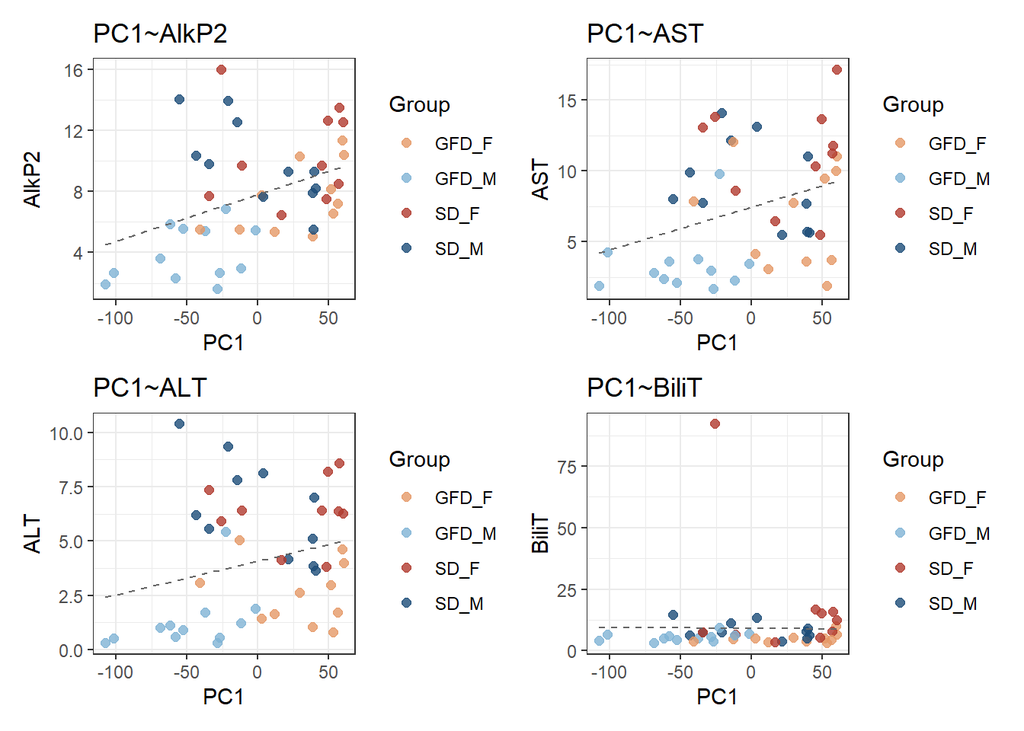

```r
p1 <- ggplot(pc_full, aes(PC1, AlkP2, colour = Group)) +
    geom_point(size = 2, alpha = 0.8) +
    geom_smooth(method = "lm", se = FALSE, colour = "grey40",
                linewidth = 0.5, linetype = "dashed") +   # overall trend
    labs(x = "PC1", y = "AlkP2", title = "PC1~AlkP2") +
    theme_bw() +
    scale_color_manual(values=group_colours)

p2 <- ggplot(pc_full, aes(PC1, as.numeric(AST), colour = Group)) +
    geom_point(size = 2, alpha = 0.8) +
    geom_smooth(method = "lm", se = FALSE, colour = "grey40",
                linewidth = 0.5, linetype = "dashed") +   # overall trend
    labs(x = "PC1", y = "AST", title = "PC1~AST") +
    theme_bw() +
    scale_color_manual(values=group_colours)

p3 <- ggplot(pc_full, aes(PC1, ALT, colour = Group)) +
    geom_point(size = 2, alpha = 0.8) +
    geom_smooth(method = "lm", se = FALSE, colour = "grey40",
                linewidth = 0.5, linetype = "dashed") +   # overall trend
    labs(x = "PC1", y = "ALT", title = "PC1~ALT") +
    theme_bw() +
    scale_color_manual(values=group_colours)

p4 <- ggplot(pc_full, aes(PC1, BiliT, colour = Group)) +
    geom_point(size = 2, alpha = 0.8) +
    geom_smooth(method = "lm", se = FALSE, colour = "grey40",
                linewidth = 0.5, linetype = "dashed") +   # overall trend
    labs(x = "PC1", y = "BiliT", title = "PC1~BiliT") +
    theme_bw() +
    scale_color_manual(values=group_colours)

p1 + p2 + p3 + p4
```

## 6.1 Group-means

**Open code**

```r
params <- read.xlsx("../../Data/P076_3_params.xlsx") %>%
  dplyr::filter(MID %in% sample_metadata$MID)

# load metadata
sample_metadata <- read.xlsx("../../Data/metadata_P076v3.xlsx",detectDates = TRUE) %>%
  dplyr::filter(!is.na(SampleIAB)) %>%
  dplyr::mutate(Group=paste(Diet,Sex,sep = "_")) %>%
  dplyr::mutate(SampleID=SampleIAB)

sample_metadata <- merge(sample_metadata,params,by="MID",all=TRUE)

# merge() renames Date to Date.x if the params table also has a Date column
if (!"Date" %in% names(sample_metadata) && "Date.x" %in% names(sample_metadata))
  sample_metadata$Date <- sample_metadata$Date.x

# same reference levels as the rest of the report (SD, F)
sample_metadata <- sample_metadata %>%
  mutate(Diet = factor(Diet, levels = c("SD", "GFD")),
         Sex  = factor(Sex,  levels = c("F", "M")),
         Date = factor(gsub("-", "_", Date)))
```

**Open code**

```r
liver_markers <- c("AST","ALT","AlkP2","BiliT")

sample_metadata[liver_markers] <- lapply(sample_metadata[liver_markers],
                                       function(x) as.numeric(as.character(x)))

# same model as the panel scores: marker ~ Diet * Sex + Date (SD and F as reference)
marker_tab <- lapply(liver_markers, function(mk){
  fit <- lm(sample_metadata[[mk]] ~ Diet * Sex + Date, data = sample_metadata)
  co  <- summary(fit)$coefficients
  int <- grep(":", rownames(co), value = TRUE)[1]
  data.frame(marker = mk,
             Interaction_est = co[int,"Estimate"],
             Interaction_p   = co[int,"Pr(>|t|)"])
}) %>% dplyr::bind_rows()

marker_tab$padj <- p.adjust(marker_tab$Interaction_p, "BH")

marker_tab
```

```
  marker Interaction_est Interaction_p      padj
1    AST       -1.239267    0.51736077 0.5173608
2    ALT       -1.453119    0.16970652 0.2557368
3  AlkP2       -2.984439    0.05044122 0.2017649
4  BiliT       10.313033    0.19180257 0.2557368
```

**Open code**

```r
# diet effect (GFD vs SD) within each sex, BH-corrected across markers x sexes
diet_tab <- lapply(liver_markers, function(mk){
  fit <- lm(sample_metadata[[mk]] ~ Diet * Sex + Date, data = sample_metadata)
  pw  <- as.data.frame(pairs(emmeans::emmeans(fit, ~ Diet | Sex), reverse = TRUE))
  data.frame(marker = mk, Sex = pw$Sex, contrast = pw$contrast,
             estimate = pw$estimate, p = pw$p.value)
}) %>% dplyr::bind_rows()

diet_tab$padj <- p.adjust(diet_tab$p, "BH")
diet_tab
```

```
  marker Sex contrast   estimate            p         padj
1    AST   F GFD - SD  -4.445058 2.423068e-03 3.876910e-03
2    AST   M GFD - SD  -5.684325 9.736346e-05 1.947269e-04
3    ALT   F GFD - SD  -3.718745 1.441720e-05 3.844585e-05
4    ALT   M GFD - SD  -5.171864 1.092888e-08 8.743106e-08
5  AlkP2   F GFD - SD  -2.915860 9.463898e-03 1.261853e-02
6  AlkP2   M GFD - SD  -5.900300 1.041655e-06 4.166620e-06
7  BiliT   F GFD - SD -13.258049 2.318641e-02 2.649875e-02
8  BiliT   M GFD - SD  -2.945016 5.857911e-01 5.857911e-01
```

**Open code**

```r
# group means and medians — are GFD_M elevated (damage) or not?
aggregate(cbind(AST, ALT, AlkP2, BiliT) ~ Group,
          data = sample_metadata,
          FUN = function(x) mean(x, na.rm = TRUE))
```

```
  Group       AST      ALT     AlkP2     BiliT
1 GFD_F  6.775455 2.640909  7.568182  5.108182
2 GFD_M  3.409167 1.295833  3.913333  5.594167
3  SD_F 11.168000 6.347000 10.427000 18.443000
4  SD_M  9.144545 6.480000  9.869091  8.464545
```

**Open code**

```r
aggregate(cbind(AST, ALT, AlkP2, BiliT) ~ Group,
          data = sample_metadata,
          FUN = function(x) median(x, na.rm = TRUE))
```

```
  Group    AST   ALT AlkP2  BiliT
1 GFD_F  7.740 2.640 7.210  4.930
2 GFD_M  2.875 0.965 3.285  5.495
3  SD_F 11.525 6.390 9.700 10.335
4  SD_M  8.010 6.210 9.310  7.580
```

**Open code**

```r
# largest bilirubin value per group (outlier check)
aggregate(BiliT ~ Group, data = sample_metadata, FUN = max)
```

```
  Group BiliT
1 GFD_F 10.16
2 GFD_M  9.36
3  SD_F 92.28
4  SD_M 14.69
```

**Open code**

```r
# helpers for inline numbers
mv <- function(mk, col, d = 2) signif(marker_tab[marker_tab$marker == mk, col], d)
dv <- function(mk, sex, col = "padj", d = 2)
  signif(diet_tab[diet_tab$marker == mk & diet_tab$Sex == sex, col], d)
bili_max <- max(sample_metadata$BiliT[sample_metadata$Group == "SD_F"], na.rm = TRUE)
```

**NoteInterpretation**

**Interaction.** No clinical liver marker (AST, ALT, AlkP2, total bilirubin) shows a Diet×Sex interaction that survives multiple-testing correction. The lowest is AlkP2 (est = -3, p = 0.05, padj = 0.2). With SD and F as reference, a negative estimate means GFD lowers AlkP2 more in males than in females.

**Diet effect.** The group means show a clear pattern that the interaction test does not capture: **GFD males have the lowest AST, ALT and AlkP2** of all groups, and GFD lowers these markers in both sexes. GFD vs SD within males: AST padj = 1.9^{-4}, ALT padj = 8.7^{-8}, AlkP2 padj = 4.2^{-6}. So the diet does show up in serum markers, mainly as lower liver-enzyme levels; what is not detectable at this n is a *sex-specific* difference in that effect.

**Bilirubin.** The SD_F mean is inflated by a single animal (BiliT = 92.28); the medians are a better summary for this marker.

# 7 Functional enrichment - Interaction genes

## 7.1 Hallmark

**Open code**

```r
library(fgsea); library(msigdbr)

# rank by the Wald statistic of the unshrunk interaction test:
# shrunk LFCs put thousands of genes at ~0 (ties), which weakens GSEA
res_int_raw <- results(dds, name = "DietGFD.SexM")

res_int_df <- as.data.frame(res_int_raw) %>%
  rownames_to_column("gene_id") %>%
  left_join(sym, by = "gene_id")

# one value per gene symbol (keep the strongest), ranked by the statistic
ranks <- res_int_df %>%
  dplyr::filter(!is.na(gene_name) & gene_name != "" & !is.na(stat)) %>%
  dplyr::group_by(gene_name) %>%
  dplyr::slice_max(abs(stat), n = 1, with_ties = FALSE) %>%
  dplyr::ungroup() %>%
  dplyr::arrange(desc(stat)) %>%
  { setNames(.$stat, .$gene_name) }

# mouse Hallmark gene sets (KEGG + Reactome below)
msig <- tryCatch(msigdbr(species = "Mus musculus", collection = "H"),   # Hallmark
                 error = function(e) msigdbr(species = "Mus musculus", category = "H"))
```

```
Using human MSigDB with ortholog mapping to mouse. Use `db_species = "MM"` for mouse-native gene sets.
```

**Open code**

```r
pathways <- split(msig$gene_symbol, msig$gs_name)

fgsea_res <- fgsea(pathways, ranks, minSize = 10, maxSize = 500, eps = 0)

fgsea_res %>%
  dplyr::filter(padj<0.05) %>%
  dplyr::arrange(desc(abs(NES))) %>%
  kable(
    caption = "Hallmark gene set significant pathways",
    digits  = 8,
    booktabs = TRUE,
    align = "llcccccc"
  ) %>%
  kable_styling(
    latex_options = c("hold_position"),
    bootstrap_options = c("striped", "hover", "condensed")
  )
```

Hallmark gene set significant pathways

| pathway | pval | padj | log2err | ES | NES | size | leadingEdge |
| --- | --- | --- | --- | --- | --- | --- | --- |
| HALLMARK_OXIDATIVE_PHOSPHORYLATION | 0.00000000 | 0.00000000 | 1.5297052 | 0.6405316 | 3.289851 | 185 | Cyc1, Gr.... |
| HALLMARK_MITOTIC_SPINDLE | 0.00000000 | 0.00000000 | 1.3110148 | -0.5574088 | -2.921539 | 198 | Pcnt, Sp.... |
| HALLMARK_UV_RESPONSE_DN | 0.00000000 | 0.00000000 | 1.0175448 | -0.5292740 | -2.649355 | 143 | Irs1, Ad.... |
| HALLMARK_APICAL_JUNCTION | 0.00000000 | 0.00000000 | 0.9759947 | -0.4760392 | -2.471289 | 183 | Sirpa, I.... |
| HALLMARK_FATTY_ACID_METABOLISM | 0.00000000 | 0.00000000 | 0.8513391 | 0.4695132 | 2.334263 | 150 | Acot8, O.... |
| HALLMARK_MYC_TARGETS_V1 | 0.00000000 | 0.00000000 | 0.8870750 | 0.4407742 | 2.288901 | 195 | Cyc1, Od.... |
| HALLMARK_G2M_CHECKPOINT | 0.00000000 | 0.00000000 | 0.8753251 | -0.4295926 | -2.252839 | 197 | Tmpo, Mc.... |
| HALLMARK_APICAL_SURFACE | 0.00000653 | 0.00002332 | 0.6105269 | -0.5636553 | -2.246017 | 40 | Pkhd1, A.... |
| HALLMARK_EPITHELIAL_MESENCHYMAL_TRANSITION | 0.00000000 | 0.00000000 | 0.8390889 | -0.4304567 | -2.233155 | 189 | Fbn2, Tn.... |
| HALLMARK_ESTROGEN_RESPONSE_EARLY | 0.00000000 | 0.00000001 | 0.7749390 | -0.4046136 | -2.097363 | 188 | Elf3, Fa.... |
| HALLMARK_TNFA_SIGNALING_VIA_NFKB | 0.00000000 | 0.00000001 | 0.7749390 | -0.3998834 | -2.095976 | 199 | Bcl6, Nf.... |
| HALLMARK_HEDGEHOG_SIGNALING | 0.00021856 | 0.00057515 | 0.5188481 | -0.5255686 | -2.012957 | 35 | Ets2, Nr.... |
| HALLMARK_WNT_BETA_CATENIN_SIGNALING | 0.00031007 | 0.00077517 | 0.4984931 | -0.5004927 | -1.994331 | 40 | Notch1, .... |
| HALLMARK_CHOLESTEROL_HOMEOSTASIS | 0.00003581 | 0.00011191 | 0.5573322 | -0.4462337 | -1.974114 | 75 | Hmgcs1, .... |
| HALLMARK_NOTCH_SIGNALING | 0.00038753 | 0.00088074 | 0.4984931 | -0.5225807 | -1.942567 | 32 | Notch1, .... |
| HALLMARK_DNA_REPAIR | 0.00000140 | 0.00000634 | 0.6435518 | 0.3905149 | 1.941920 | 149 | Polr2c, .... |
| HALLMARK_ADIPOGENESIS | 0.00000228 | 0.00000948 | 0.6272567 | 0.3630593 | 1.886871 | 194 | Esrra, C.... |
| HALLMARK_REACTIVE_OXYGEN_SPECIES_PATHWAY | 0.00173042 | 0.00332773 | 0.4550599 | 0.4494252 | 1.836822 | 48 | Cdkn2d, .... |
| HALLMARK_E2F_TARGETS | 0.00000303 | 0.00001165 | 0.6272567 | -0.3491167 | -1.829884 | 199 | Nup205, .... |
| HALLMARK_TGF_BETA_SIGNALING | 0.00105411 | 0.00210822 | 0.4550599 | -0.4285060 | -1.784196 | 52 | Ctnnb1, .... |
| HALLMARK_MYOGENESIS | 0.00001273 | 0.00004243 | 0.5933255 | -0.3419585 | -1.765265 | 176 | Notch1, .... |
| HALLMARK_XENOBIOTIC_METABOLISM | 0.00016174 | 0.00044929 | 0.5188481 | 0.3209300 | 1.668783 | 196 | Arg1, Gs.... |
| HALLMARK_INFLAMMATORY_RESPONSE | 0.00012582 | 0.00037006 | 0.5188481 | -0.3189400 | -1.658418 | 186 | Osmr, Cy.... |
| HALLMARK_ANDROGEN_RESPONSE | 0.00281520 | 0.00521334 | 0.4317077 | -0.3431067 | -1.607734 | 100 | Hmgcs1, .... |
| HALLMARK_HYPOXIA | 0.00037864 | 0.00088074 | 0.4984931 | -0.3060289 | -1.590595 | 192 | Tnfaip3,.... |
| HALLMARK_IL6_JAK_STAT3_SIGNALING | 0.00568871 | 0.00948119 | 0.4070179 | -0.3442981 | -1.577723 | 86 | Osmr, Cs.... |
| HALLMARK_COMPLEMENT | 0.00098769 | 0.00205768 | 0.4550599 | -0.3015767 | -1.564542 | 189 | Tnfaip3,.... |
| HALLMARK_MYC_TARGETS_V2 | 0.01741459 | 0.02721030 | 0.3524879 | 0.3671525 | 1.547186 | 57 | Exosc5, .... |
| HALLMARK_ANGIOGENESIS | 0.02711630 | 0.03987691 | 0.3524879 | -0.3961373 | -1.537229 | 36 | Col5a2, .... |
| HALLMARK_KRAS_SIGNALING_UP | 0.00079040 | 0.00171826 | 0.4772708 | -0.2940330 | -1.524883 | 190 | Tnfaip3,.... |
| HALLMARK_KRAS_SIGNALING_DN | 0.00452179 | 0.00779620 | 0.4070179 | -0.2994980 | -1.486494 | 133 | Ybx2, Ab.... |
| HALLMARK_APOPTOSIS | 0.00309586 | 0.00552832 | 0.4317077 | -0.2931655 | -1.482790 | 156 | Ctnnb1, .... |
| HALLMARK_UNFOLDED_PROTEIN_RESPONSE | 0.02036482 | 0.03085579 | 0.3524879 | 0.3073938 | 1.457698 | 109 | Psat1, E.... |
| HALLMARK_ESTROGEN_RESPONSE_LATE | 0.00891710 | 0.01438242 | 0.3807304 | -0.2738790 | -1.419951 | 187 | Emp2, Ad.... |

Saving the result

**Open code**

```r
hallmark_int <- fgsea_res
write.xlsx(fgsea_res,"../Results/fe_hallmark.xlsx",rownames=FALSE)
```

## 7.2 KEGG & REACTOME

The same GSEA is run with two larger, more detailed collections:

- **KEGG** (legacy MSigDB version): curated metabolic and signaling pathway maps.
- **Reactome**: pathways curated at the level of individual reactions, organized in a hierarchy from broad to narrow processes.

The helper `get_sets()` downloads the gene sets and works with both the newer and older `msigdbr` interfaces. Sets with 5–500 genes are tested; the tables show sets with padj < 0.05, sorted by |NES|. `set.seed()` makes the permutation-based p-values reproducible.

**Open code**

```r
# Pull KEGG + Reactome gene sets (mouse)
get_sets <- function(coll, subcoll) {
  out <- tryCatch(
    msigdbr(species = "Mus musculus", collection = coll, subcollection = subcoll),
    error = function(e)
      msigdbr(species = "Mus musculus", category = coll, subcategory = subcoll)
  )
  split(out$gene_symbol, out$gs_name)
}

kegg     <- tryCatch(get_sets("C2", "CP:KEGG_LEGACY"), error = function(e) get_sets("C2","CP:KEGG"))
reactome <- get_sets("C2", "CP:REACTOME")

#  Run fgsea on each collection
set.seed(123)
kegg_res <- fgsea(kegg, ranks, minSize = 5, maxSize = 500, eps = 0)

react_res <- fgsea(reactome, ranks, minSize = 5, maxSize = 500, eps = 0)
```

**Open code**

```r
kegg_res %>%
  dplyr::filter(padj<0.05) %>%
  dplyr::arrange(desc(abs(NES))) %>%
  kable(
    caption = "KEGG db significant pathways",
    digits  = 8,
    booktabs = TRUE,
    align = "llcccccc"
  ) %>%
  kable_styling(
    latex_options = c("hold_position"),
    bootstrap_options = c("striped", "hover", "condensed")
  )
```

KEGG db significant pathways

| pathway | pval | padj | log2err | ES | NES | size | leadingEdge |
| --- | --- | --- | --- | --- | --- | --- | --- |
| KEGG_RIBOSOME | 0.00000000 | 0.00000000 | 1.4099514 | 0.7684775 | 3.480600 | 83 | Rpl36, R.... |
| KEGG_OXIDATIVE_PHOSPHORYLATION | 0.00000000 | 0.00000000 | 1.1601796 | 0.6449308 | 3.066152 | 107 | Cyc1, Co.... |
| KEGG_PARKINSONS_DISEASE | 0.00000000 | 0.00000000 | 1.0959293 | 0.6122804 | 2.917779 | 108 | Cyc1, Co.... |
| KEGG_FOCAL_ADHESION | 0.00000000 | 0.00000000 | 1.1053366 | -0.5147803 | -2.721052 | 189 | Ctnnb1, .... |
| KEGG_PROTEASOME | 0.00000000 | 0.00000001 | 0.8140358 | 0.6803287 | 2.674999 | 43 | Psmd4, P.... |
| KEGG_REGULATION_OF_ACTIN_CYTOSKELETON | 0.00000000 | 0.00000000 | 1.0476265 | -0.4941306 | -2.618097 | 190 | Itgax, P.... |
| KEGG_PHOSPHATIDYLINOSITOL_SIGNALING_SYSTEM | 0.00000000 | 0.00000001 | 0.7881868 | -0.5745586 | -2.557093 | 71 | Dgke, Pi.... |
| KEGG_ECM_RECEPTOR_INTERACTION | 0.00000000 | 0.00000000 | 0.8140358 | -0.5674760 | -2.549803 | 77 | Col5a2, .... |
| KEGG_AXON_GUIDANCE | 0.00000000 | 0.00000000 | 0.8753251 | -0.5008297 | -2.472798 | 121 | Epha2, N.... |
| KEGG_ADHERENS_JUNCTION | 0.00000001 | 0.00000012 | 0.7477397 | -0.5410550 | -2.426495 | 73 | Ctnnb1, .... |
| KEGG_HUNTINGTONS_DISEASE | 0.00000000 | 0.00000000 | 0.8513391 | 0.4700224 | 2.369991 | 153 | Polr2c, .... |
| KEGG_PATHWAYS_IN_CANCER | 0.00000000 | 0.00000000 | 1.0276699 | -0.4171084 | -2.357528 | 306 | Ctnnb1, .... |
| KEGG_JAK_STAT_SIGNALING_PATHWAY | 0.00000000 | 0.00000001 | 0.8140358 | -0.4840012 | -2.353488 | 113 | Osmr, Pi.... |
| KEGG_ARRHYTHMOGENIC_RIGHT_VENTRICULAR_CARDIOMYOPATHY_ARVC | 0.00000010 | 0.00000088 | 0.7049757 | -0.5284659 | -2.343612 | 66 | Ctnnb1, .... |
| KEGG_B_CELL_RECEPTOR_SIGNALING_PATHWAY | 0.00000002 | 0.00000019 | 0.7337620 | -0.5201250 | -2.332936 | 74 | Cr2, Dap.... |
| KEGG_ABC_TRANSPORTERS | 0.00000467 | 0.00002894 | 0.6105269 | -0.5868656 | -2.271653 | 37 | Abcb1a, .... |
| KEGG_ALZHEIMERS_DISEASE | 0.00000000 | 0.00000002 | 0.7881868 | 0.4532442 | 2.255281 | 141 | Cyc1, Co.... |
| KEGG_LEUKOCYTE_TRANSENDOTHELIAL_MIGRATION | 0.00000003 | 0.00000028 | 0.7337620 | -0.4713133 | -2.248142 | 105 | Ctnnb1, .... |
| KEGG_FC_GAMMA_R_MEDIATED_PHAGOCYTOSIS | 0.00000008 | 0.00000072 | 0.7049757 | -0.4810732 | -2.246707 | 92 | Pik3ca, .... |
| KEGG_SMALL_CELL_LUNG_CANCER | 0.00000012 | 0.00000095 | 0.6901325 | -0.4884412 | -2.235876 | 83 | Pik3ca, .... |
| KEGG_PANCREATIC_CANCER | 0.00000038 | 0.00000260 | 0.6749629 | -0.4999412 | -2.224855 | 70 | Pik3ca, .... |
| KEGG_TIGHT_JUNCTION | 0.00000007 | 0.00000068 | 0.7049757 | -0.4499793 | -2.193796 | 114 | Ctnnb1, .... |
| KEGG_CHEMOKINE_SIGNALING_PATHWAY | 0.00000000 | 0.00000002 | 0.7881868 | -0.4225623 | -2.186176 | 170 | Adcy7, A.... |
| KEGG_PEROXISOME | 0.00000170 | 0.00001129 | 0.6435518 | 0.4840935 | 2.172396 | 76 | Acot8, D.... |
| KEGG_ENDOMETRIAL_CANCER | 0.00000847 | 0.00004682 | 0.5933255 | -0.5176706 | -2.151990 | 52 | Ctnnb1, .... |
| KEGG_MAPK_SIGNALING_PATHWAY | 0.00000000 | 0.00000000 | 0.8266573 | -0.3928313 | -2.151418 | 239 | Dusp16, .... |
| KEGG_INOSITOL_PHOSPHATE_METABOLISM | 0.00000564 | 0.00003277 | 0.6105269 | -0.5138671 | -2.151026 | 53 | Pik3ca, .... |
| KEGG_NEUROTROPHIN_SIGNALING_PATHWAY | 0.00000014 | 0.00000104 | 0.6901325 | -0.4341486 | -2.145340 | 122 | Camk4, I.... |
| KEGG_COLORECTAL_CANCER | 0.00000856 | 0.00004682 | 0.5933255 | -0.4939682 | -2.133691 | 61 | Ctnnb1, .... |
| KEGG_ALDOSTERONE_REGULATED_SODIUM_REABSORPTION | 0.00008598 | 0.00034027 | 0.5384341 | -0.5607718 | -2.129080 | 34 | Irs1, At.... |

[output cut: 64 more lines]

Saving results.

**Open code**

```r
write.xlsx(kegg_res,"../Results/fe_kegg.xlsx",rownames=FALSE)
```

**Open code**

```r
react_res %>%
  dplyr::filter(padj<0.05) %>%
  dplyr::arrange(desc(abs(NES))) %>%
  kable(
    caption = "Reactome db significant pathways",
    digits  = 8,
    booktabs = TRUE,
    align = "llcccccc"
  ) %>%
  kable_styling(
    latex_options = c("hold_position"),
    bootstrap_options = c("striped", "hover", "condensed")
  )
```

Reactome db significant pathways

| pathway | pval | padj | log2err | ES | NES | size | leadingEdge |
| --- | --- | --- | --- | --- | --- | --- | --- |
| REACTOME_TRANSLATION | 0.00000000 | 0.00000000 | 2.0452397 | 0.6303233 | 3.487737 | 346 | Mrps35, .... |
| REACTOME_MITOCHONDRIAL_TRANSLATION_ELONGATION | 0.00000000 | 0.00000000 | 1.4245627 | 0.7589457 | 3.428078 | 87 | Mrps35, .... |
| REACTOME_SELENOAMINO_ACID_METABOLISM | 0.00000000 | 0.00000000 | 1.4533447 | 0.7315324 | 3.425363 | 104 | Nnmt, Rp.... |
| REACTOME_EUKARYOTIC_TRANSLATION_ELONGATION | 0.00000000 | 0.00000000 | 1.4172759 | 0.7545409 | 3.414304 | 88 | Rpl36, R.... |
| REACTOME_SRP_DEPENDENT_COTRANSLATIONAL_PROTEIN_TARGETING_TO_MEMBRANE | 0.00000000 | 0.00000000 | 1.4390257 | 0.7242999 | 3.402795 | 106 | Rpl36, R.... |
| REACTOME_RESPIRATORY_ELECTRON_TRANSPORT | 0.00000000 | 0.00000000 | 1.5631820 | 0.6835883 | 3.386819 | 152 | Cyc1, Hs.... |
| REACTOME_MITOCHONDRIAL_TRANSLATION | 0.00000000 | 0.00000000 | 1.4390257 | 0.7163570 | 3.384235 | 112 | Mrps35, .... |
| REACTOME_RESPONSE_OF_EIF2AK4_GCN2_TO_AMINO_ACID_DEFICIENCY | 0.00000000 | 0.00000000 | 1.3877461 | 0.7280827 | 3.360790 | 96 | Rpl36, R.... |
| REACTOME_EUKARYOTIC_TRANSLATION_INITIATION | 0.00000000 | 0.00000000 | 1.4245627 | 0.7082899 | 3.359287 | 115 | Eif3h, E.... |
| REACTOME_RIBOSOME_ASSOCIATED_QUALITY_CONTROL | 0.00000000 | 0.00000000 | 1.4245627 | 0.6654058 | 3.274446 | 139 | Rpl36, R.... |
| REACTOME_AEROBIC_RESPIRATION_AND_RESPIRATORY_ELECTRON_TRANSPORT | 0.00000000 | 0.00000000 | 1.5297052 | 0.5945820 | 3.139998 | 232 | Cyc1, Ha.... |
| REACTOME_REGULATION_OF_EXPRESSION_OF_SLITS_AND_ROBOS | 0.00000000 | 0.00000000 | 1.3188888 | 0.6248973 | 3.093555 | 150 | Rpl36, R.... |
| REACTOME_METABOLISM_OF_AMINO_ACIDS_AND_DERIVATIVES | 0.00000000 | 0.00000000 | 1.6216995 | 0.5581593 | 3.074918 | 321 | Psat1, O.... |
| REACTOME_COMPLEX_I_BIOGENESIS | 0.00000000 | 0.00000000 | 1.0959293 | 0.7064042 | 3.045737 | 67 | Hscb, Nd.... |
| REACTOME_RIBOSOME_QUALITY_CONTROL_RQC_COMPLEX_EXTRACTS_AND_DEGRADES_NASCENT_PEPTIDE | 0.00000000 | 0.00000000 | 1.1512205 | 0.6515970 | 3.024300 | 99 | Rpl36, R.... |
| REACTOME_RRNA_PROCESSING | 0.00000000 | 0.00000000 | 1.3727430 | 0.5806219 | 3.023790 | 203 | Trub2, E.... |
| REACTOME_CELLULAR_RESPONSE_TO_STARVATION | 0.00000000 | 0.00000000 | 1.2790340 | 0.6120738 | 3.009891 | 147 | Rpl36, R.... |
| REACTOME_MITOCHONDRIAL_PROTEIN_IMPORT | 0.00000000 | 0.00000000 | 1.0073180 | 0.6979465 | 2.975721 | 61 | Cyc1, Gr.... |
| REACTOME_ACTIVATION_OF_THE_MRNA_UPON_BINDING_OF_THE_CAP_BINDING_COMPLEX_AND_EIFS_AND_SUBSEQUENT_BINDING_TO_43S | 0.00000000 | 0.00000000 | 1.0073180 | 0.6977903 | 2.961286 | 59 | Eif3h, E.... |
| REACTOME_CDC42_GTPASE_CYCLE | 0.00000000 | 0.00000000 | 1.2039752 | -0.5807578 | -2.955170 | 150 | Fmnl2, T.... |
| REACTOME_NONSENSE_MEDIATED_DECAY_NMD | 0.00000000 | 0.00000000 | 1.1053366 | 0.6168989 | 2.911137 | 110 | Rpl36, R.... |
| REACTOME_EXTRACELLULAR_MATRIX_ORGANIZATION | 0.00000000 | 0.00000000 | 1.4318125 | -0.5207317 | -2.884699 | 286 | Fbn2, Ad.... |
| REACTOME_RAC1_GTPASE_CYCLE | 0.00000000 | 0.00000000 | 1.2125446 | -0.5471090 | -2.850739 | 181 | Epha2, T.... |
| REACTOME_PROTEASOME_ASSEMBLY | 0.00000000 | 0.00000000 | 0.9214260 | 0.7037281 | 2.845870 | 50 | Psmg1, P.... |
| REACTOME_SARS_COV_1_MODULATES_HOST_TRANSLATION_MACHINERY | 0.00000000 | 0.00000000 | 0.8753251 | 0.7482544 | 2.823052 | 35 | Rpsa, Rp.... |
| REACTOME_ECM_PROTEOGLYCANS | 0.00000000 | 0.00000000 | 0.9436322 | -0.6446643 | -2.821806 | 66 | Col5a2, .... |
| REACTOME_COLLAGEN_CHAIN_TRIMERIZATION | 0.00000000 | 0.00000000 | 0.8753251 | -0.7260507 | -2.791742 | 38 | Col5a2, .... |
| REACTOME_SARS_COV_2_MODULATES_HOST_TRANSLATION_MACHINERY | 0.00000000 | 0.00000000 | 0.8870750 | 0.6952438 | 2.786964 | 48 | Gemin2, .... |
| REACTOME_COMPLEX_IV_ASSEMBLY | 0.00000000 | 0.00000000 | 0.8870750 | 0.7004295 | 2.756067 | 45 | Cox4i1, .... |
| REACTOME_RHO_GTPASE_CYCLE | 0.00000000 | 0.00000000 | 1.4815676 | -0.4736777 | -2.755266 | 437 | Fmnl2, E.... |

[output cut: 561 more lines]

Saving the results

**Open code**

```r
write.xlsx(react_res,"../Results/fe_reactome.xlsx",rownames=FALSE)
```

## 7.3 Specific pathway-focused

**Open code**

```r
# Focus on bile-acid / lipid / sterol pathways
focus <- "BILE|CHOLESTEROL|STEROL|STEROID|FATTY_ACID|LIPID|PPAR|OXIDATION|MITOCHOND|OXIDATIVE_PHOS|TRIGLYCERIDE|LIPOGEN"

kegg_focus <- kegg_res %>% dplyr::filter(grepl(focus, pathway, ignore.case = TRUE))
react_focus <- react_res %>% dplyr::filter(grepl(focus, pathway, ignore.case = TRUE))

cat("KEGG: metabolic pathways\n")
```

```
KEGG: metabolic pathways
```

**Open code**

```r
kegg_focus %>% dplyr::select(pathway, pval, padj, NES, size)  %>%
  dplyr::arrange(desc(abs(NES))) %>%
  kable(
    caption = "KEGG db selected pathways",
    digits  = 8,
    booktabs = TRUE,
    align = "llcccccc"
  ) %>%
  kable_styling(
    latex_options = c("hold_position"),
    bootstrap_options = c("striped", "hover", "condensed")
  )
```

KEGG db selected pathways

| pathway | pval | padj | NES | size |
| --- | --- | --- | --- | --- |
| KEGG_OXIDATIVE_PHOSPHORYLATION | 0.00000000 | 0.00000000 | 3.0661524 | 107 |
| KEGG_STEROID_HORMONE_BIOSYNTHESIS | 0.00016465 | 0.00057781 | 1.9844951 | 45 |
| KEGG_STEROID_BIOSYNTHESIS | 0.00121580 | 0.00344702 | -1.9702049 | 16 |
| KEGG_GLYCEROPHOSPHOLIPID_METABOLISM | 0.00009279 | 0.00035956 | -1.9500294 | 68 |
| KEGG_PRIMARY_BILE_ACID_BIOSYNTHESIS | 0.05109964 | 0.08610191 | 1.5497684 | 17 |
| KEGG_FATTY_ACID_METABOLISM | 0.02652693 | 0.05185733 | 1.5124100 | 38 |
| KEGG_GLYCEROLIPID_METABOLISM | 0.02760148 | 0.05185733 | -1.4782473 | 41 |
| KEGG_BIOSYNTHESIS_OF_UNSATURATED_FATTY_ACIDS | 0.23430962 | 0.29054393 | -1.1748889 | 23 |
| KEGG_ETHER_LIPID_METABOLISM | 0.24324324 | 0.29962413 | -1.1673463 | 26 |
| KEGG_SPHINGOLIPID_METABOLISM | 0.42685371 | 0.48411457 | -1.0131404 | 35 |
| KEGG_GLYCOSPHINGOLIPID_BIOSYNTHESIS_GLOBO_SERIES | 0.61660079 | 0.65071708 | 0.8932989 | 14 |
| KEGG_PPAR_SIGNALING_PATHWAY | 0.67943548 | 0.70600559 | -0.8923011 | 62 |
| KEGG_GLYCOSPHINGOLIPID_BIOSYNTHESIS_LACTO_AND_NEOLACTO_SERIES | 0.71755725 | 0.73737928 | 0.8225376 | 23 |
| KEGG_GLYCOSPHINGOLIPID_BIOSYNTHESIS_GANGLIO_SERIES | 0.81578947 | 0.82916307 | -0.7429913 | 13 |

**Open code**

```r
cat("Reactome: metabolic pathways\n")
```

```
Reactome: metabolic pathways
```

**Open code**

```r
react_focus %>% dplyr::select(pathway, pval, padj, NES, size) %>%
  dplyr::arrange(desc(abs(NES))) %>%
  kable(
    caption = "Reactome db selected pathways",
    digits  = 8,
    booktabs = TRUE,
    align = "llcccccc"
  ) %>%
  kable_styling(
    latex_options = c("hold_position"),
    bootstrap_options = c("striped", "hover", "condensed")
)
```

Reactome db selected pathways

| pathway | pval | padj | NES | size |
| --- | --- | --- | --- | --- |
| REACTOME_MITOCHONDRIAL_TRANSLATION_ELONGATION | 0.00000000 | 0.00000000 | 3.4280780 | 87 |
| REACTOME_MITOCHONDRIAL_TRANSLATION | 0.00000000 | 0.00000000 | 3.3842348 | 112 |
| REACTOME_MITOCHONDRIAL_PROTEIN_IMPORT | 0.00000000 | 0.00000000 | 2.9757206 | 61 |
| REACTOME_REGULATION_OF_CHOLESTEROL_BIOSYNTHESIS_BY_SREBP_SREBF | 0.00000005 | 0.00000120 | -2.4062827 | 56 |
| REACTOME_MITOCHONDRIAL_PROTEIN_DEGRADATION | 0.00000002 | 0.00000046 | 2.3103569 | 91 |
| REACTOME_CHOLESTEROL_BIOSYNTHESIS | 0.00001334 | 0.00013055 | -2.2893192 | 26 |
| REACTOME_BIOLOGICAL_OXIDATIONS | 0.00000000 | 0.00000000 | 2.2194312 | 184 |
| REACTOME_RRNA_MODIFICATION_IN_THE_MITOCHONDRION | 0.00018109 | 0.00127420 | 2.0828409 | 13 |
| REACTOME_MITOCHONDRIAL_IRON_SULFUR_CLUSTER_BIOGENESIS | 0.00060676 | 0.00354349 | 1.9793132 | 13 |
| REACTOME_ROLE_OF_PHOSPHOLIPIDS_IN_PHAGOCYTOSIS | 0.00031540 | 0.00200763 | -1.9615944 | 48 |
| REACTOME_RRNA_PROCESSING_IN_THE_MITOCHONDRION | 0.00084302 | 0.00465921 | 1.9580214 | 17 |
| REACTOME_CHOLESTEROL_BIOSYNTHESIS_VIA_DESMOSTEROL_BLOCH_PATHWAY | 0.00196373 | 0.00945182 | -1.9193845 | 10 |
| REACTOME_PEROXISOMAL_LIPID_METABOLISM | 0.00072735 | 0.00411069 | 1.9125810 | 27 |
| REACTOME_NR1H3_NR1H2_REGULATE_GENE_EXPRESSION_LINKED_TO_CHOLESTEROL_TRANSPORT_AND_EFFLUX | 0.00061578 | 0.00358423 | -1.9034946 | 35 |
| REACTOME_PHOSPHOLIPID_METABOLISM | 0.00000057 | 0.00000919 | -1.8996916 | 195 |
| REACTOME_MITOCHONDRIAL_FATTY_ACID_BETA_OXIDATION | 0.00056595 | 0.00333856 | 1.8943831 | 37 |
| REACTOME_MITOCHONDRIAL_MRNA_MODIFICATION | 0.00193263 | 0.00935348 | 1.8900609 | 10 |
| REACTOME_CELLULAR_RESPONSE_TO_MITOCHONDRIAL_STRESS | 0.00375157 | 0.01596325 | 1.8714818 | 9 |
| REACTOME_LANOSTEROL_BIOSYNTHESIS | 0.00367925 | 0.01572205 | -1.8343167 | 13 |
| REACTOME_MITOCHONDRIAL_FATTY_ACID_BETA_OXIDATION_OF_SATURATED_FATTY_ACIDS | 0.00407010 | 0.01681795 | 1.8340769 | 10 |
| REACTOME_LIPID_PARTICLE_ORGANIZATION | 0.00625618 | 0.02337063 | 1.7909455 | 6 |
| REACTOME_ABC_TRANSPORTERS_IN_LIPID_HOMEOSTASIS | 0.01383925 | 0.04268727 | -1.7681319 | 16 |
| REACTOME_BETA_OXIDATION_OF_DECANOYL_COA_TO_OCTANOYL_COA_COA | 0.01702708 | 0.05022127 | 1.6932049 | 6 |
| REACTOME_BIOSYNTHESIS_OF_THE_N_GLYCAN_PRECURSOR_DOLICHOL_LIPID_LINKED_OLIGOSACCHARIDE_LLO_AND_TRANSFER_TO_A_NASCENT_PROTEIN | 0.00215234 | 0.01013683 | 1.6835710 | 73 |
| REACTOME_ZYMOSTENOL_BIOSYNTHESIS_VIA_LATHOSTEROL_KANDUTSCH_RUSSELL_PATHWAY | 0.01451754 | 0.04438870 | -1.6730414 | 8 |
| REACTOME_METABOLISM_OF_STEROIDS | 0.00073319 | 0.00413040 | -1.6447868 | 144 |
| REACTOME_ACTIVATION_OF_PUMA_AND_TRANSLOCATION_TO_MITOCHONDRIA | 0.01980836 | 0.05561578 | -1.6357490 | 8 |
| REACTOME_SYNTHESIS_OF_BILE_ACIDS_AND_BILE_SALTS_VIA_24_HYDROXYCHOLESTEROL | 0.02201415 | 0.06035803 | 1.6018927 | 12 |
| REACTOME_ALPHA_OXIDATION_OF_PHYTANATE | 0.03322721 | 0.08210729 | 1.5984239 | 6 |
| REACTOME_TRANSCRIPTIONAL_ACTIVATION_OF_MITOCHONDRIAL_BIOGENESIS | 0.01031470 | 0.03435617 | -1.5834207 | 52 |

[output cut: 52 more lines]

# 8 Functional enrichment - Diet effect in males genes

## 8.1 Hallmark

**Open code**

```r
library(fgsea); library(msigdbr)

# rank by the Wald statistic of the unshrunk diet-in-males contrast
res_M_raw <- results(dds, contrast = list(c("Diet_GFD_vs_SD", "DietGFD.SexM")))

res_M_df <- as.data.frame(res_M_raw) %>%
  rownames_to_column("gene_id") %>%
  left_join(sym, by = "gene_id")

# one value per gene symbol (keep the strongest), ranked by the statistic
ranks <- res_M_df %>%
  dplyr::filter(!is.na(gene_name) & gene_name != "" & !is.na(stat)) %>%
  dplyr::group_by(gene_name) %>%
  dplyr::slice_max(abs(stat), n = 1, with_ties = FALSE) %>%
  dplyr::ungroup() %>%
  dplyr::arrange(desc(stat)) %>%
  { setNames(.$stat, .$gene_name) }

# mouse Hallmark gene sets (KEGG + Reactome below)
msig <- tryCatch(msigdbr(species = "Mus musculus", collection = "H"),   # Hallmark
                 error = function(e) msigdbr(species = "Mus musculus", category = "H"))
pathways <- split(msig$gene_symbol, msig$gs_name)

fgsea_res <- fgsea(pathways, ranks, minSize = 10, maxSize = 500, eps = 0)

fgsea_res %>%
  dplyr::filter(padj<0.05) %>%
  dplyr::arrange(desc(abs(NES))) %>%
  kable(
    caption = "Hallmark gene set significant pathways",
    digits  = 8,
    booktabs = TRUE,
    align = "llcccccc"
  ) %>%
  kable_styling(
    latex_options = c("hold_position"),
    bootstrap_options = c("striped", "hover", "condensed")
  )
```

Hallmark gene set significant pathways

| pathway | pval | padj | log2err | ES | NES | size | leadingEdge |
| --- | --- | --- | --- | --- | --- | --- | --- |
| HALLMARK_OXIDATIVE_PHOSPHORYLATION | 0.00000000 | 0.00000000 | 1.6216995 | 0.6753764 | 3.253417 | 185 | Acat1, D.... |
| HALLMARK_MITOTIC_SPINDLE | 0.00000000 | 0.00000000 | 1.3422338 | -0.5803009 | -2.994155 | 198 | Sptan1, .... |
| HALLMARK_CHOLESTEROL_HOMEOSTASIS | 0.00000000 | 0.00000000 | 0.9545416 | -0.6344230 | -2.776938 | 75 | Hmgcs1, .... |
| HALLMARK_UV_RESPONSE_DN | 0.00000000 | 0.00000000 | 0.9545416 | -0.5172271 | -2.547241 | 143 | Cav1, Ir.... |
| HALLMARK_APICAL_JUNCTION | 0.00000000 | 0.00000000 | 0.9865463 | -0.4943902 | -2.497966 | 183 | Sirpa, M.... |
| HALLMARK_FATTY_ACID_METABOLISM | 0.00000000 | 0.00000000 | 0.9865463 | 0.5356629 | 2.495413 | 150 | Tdo2, Hs.... |
| HALLMARK_EPITHELIAL_MESENCHYMAL_TRANSITION | 0.00000000 | 0.00000000 | 1.0276699 | -0.4893883 | -2.493389 | 189 | Eln, Tnf.... |
| HALLMARK_TNFA_SIGNALING_VIA_NFKB | 0.00000000 | 0.00000000 | 0.9759947 | -0.4704659 | -2.427946 | 199 | Cdkn1a, .... |
| HALLMARK_ESTROGEN_RESPONSE_EARLY | 0.00000000 | 0.00000000 | 0.8870750 | -0.4565728 | -2.321110 | 188 | Elf3, Dh.... |
| HALLMARK_MYC_TARGETS_V1 | 0.00000000 | 0.00000000 | 0.8870750 | 0.4641920 | 2.245418 | 195 | Odc1, Cy.... |
| HALLMARK_G2M_CHECKPOINT | 0.00000000 | 0.00000000 | 0.8266573 | -0.4172953 | -2.150954 | 197 | Sqle, Mk.... |
| HALLMARK_INFLAMMATORY_RESPONSE | 0.00000002 | 0.00000007 | 0.7337620 | -0.4025176 | -2.043172 | 186 | Cdkn1a, .... |
| HALLMARK_APICAL_SURFACE | 0.00024660 | 0.00045667 | 0.4984931 | -0.5268881 | -2.032544 | 40 | Scube1, .... |
| HALLMARK_MYOGENESIS | 0.00000006 | 0.00000023 | 0.7049757 | -0.4029794 | -2.028670 | 176 | Cdkn1a, .... |
| HALLMARK_HEDGEHOG_SIGNALING | 0.00021521 | 0.00041386 | 0.5188481 | -0.5389699 | -2.028627 | 35 | Ets2, Rt.... |
| HALLMARK_ADIPOGENESIS | 0.00000007 | 0.00000026 | 0.7049757 | 0.4095067 | 1.983101 | 194 | Ak2, Esr.... |
| HALLMARK_HYPOXIA | 0.00000012 | 0.00000041 | 0.6901325 | -0.3865177 | -1.972541 | 192 | Cdkn1a, .... |
| HALLMARK_NOTCH_SIGNALING | 0.00064174 | 0.00114597 | 0.4772708 | -0.5283896 | -1.948917 | 32 | Dtx4, Cc.... |
| HALLMARK_XENOBIOTIC_METABOLISM | 0.00000016 | 0.00000050 | 0.6901325 | 0.3997771 | 1.933076 | 196 | Abhd6, T.... |
| HALLMARK_DNA_REPAIR | 0.00000267 | 0.00000784 | 0.6272567 | 0.4050661 | 1.887910 | 149 | Pole4, P.... |
| HALLMARK_ANDROGEN_RESPONSE | 0.00007174 | 0.00017081 | 0.5384341 | -0.3987046 | -1.832411 | 100 | Hmgcs1, .... |
| HALLMARK_TGF_BETA_SIGNALING | 0.00081502 | 0.00140521 | 0.4772708 | -0.4448349 | -1.820583 | 52 | Thbs1, S.... |
| HALLMARK_IL6_JAK_STAT3_SIGNALING | 0.00018125 | 0.00036250 | 0.5188481 | -0.3957903 | -1.778418 | 86 | Osmr, Il.... |
| HALLMARK_BILE_ACID_METABOLISM | 0.00011482 | 0.00026011 | 0.5384341 | 0.3907965 | 1.746097 | 111 | Dio1, Pe.... |
| HALLMARK_WNT_BETA_CATENIN_SIGNALING | 0.00445008 | 0.00635725 | 0.4070179 | -0.4517934 | -1.742855 | 40 | Adam17, .... |
| HALLMARK_APOPTOSIS | 0.00011965 | 0.00026011 | 0.5384341 | -0.3490718 | -1.735882 | 156 | Cdkn1a, .... |
| HALLMARK_COMPLEMENT | 0.00001299 | 0.00003607 | 0.5933255 | -0.3404054 | -1.734335 | 189 | Cr2, Cp,.... |
| HALLMARK_ESTROGEN_RESPONSE_LATE | 0.00002433 | 0.00006404 | 0.5756103 | -0.3404283 | -1.723985 | 187 | Emp2, Dh.... |
| HALLMARK_INTERFERON_GAMMA_RESPONSE | 0.00003386 | 0.00008466 | 0.5573322 | -0.3316900 | -1.716968 | 200 | Cdkn1a, .... |
| HALLMARK_REACTIVE_OXYGEN_SPECIES_PATHWAY | 0.00228421 | 0.00335913 | 0.4317077 | 0.4457443 | 1.699621 | 48 | Glrx, So.... |
| HALLMARK_ANGIOGENESIS | 0.00997435 | 0.01385327 | 0.3807304 | -0.4488322 | -1.698840 | 36 | Col5a2, .... |
| HALLMARK_INTERFERON_ALPHA_RESPONSE | 0.00199179 | 0.00301787 | 0.4317077 | -0.3541267 | -1.631967 | 99 | Cmpk2, H.... |
| HALLMARK_KRAS_SIGNALING_UP | 0.00016160 | 0.00033667 | 0.5188481 | -0.3182283 | -1.622432 | 190 | Tnfaip3,.... |
| HALLMARK_KRAS_SIGNALING_DN | 0.00171494 | 0.00276603 | 0.4550599 | -0.3204184 | -1.553751 | 133 | Mthfr, M.... |
| HALLMARK_P53_PATHWAY | 0.00115096 | 0.00191827 | 0.4550599 | -0.2908313 | -1.499094 | 197 | Cdkn1a, .... |
| HALLMARK_IL2_STAT5_SIGNALING | 0.00193791 | 0.00301787 | 0.4550599 | -0.2846022 | -1.458423 | 195 | Bcl2, Ab.... |
| HALLMARK_PEROXISOME | 0.01295675 | 0.01750912 | 0.3807304 | 0.3297446 | 1.430931 | 94 | Dio1, Pe.... |
| HALLMARK_COAGULATION | 0.02167019 | 0.02778229 | 0.3524879 | -0.2831933 | -1.373059 | 135 | Thbs1, C.... |
| HALLMARK_MTORC1_SIGNALING | 0.01515295 | 0.01993809 | 0.3807304 | -0.2578722 | -1.329205 | 197 | Hmgcs1, .... |
| HALLMARK_GLYCOLYSIS | 0.02841479 | 0.03509754 | 0.3524879 | -0.2529527 | -1.290910 | 192 | Pygb, El.... |
| HALLMARK_HEME_METABOLISM | 0.04193548 | 0.04992320 | 0.2820133 | 0.2676332 | 1.289240 | 185 | Gde1, Fn.... |
| HALLMARK_E2F_TARGETS | 0.02877998 | 0.03509754 | 0.3524879 | -0.2458983 | -1.269014 | 199 | Cdkn1a, .... |

Saving the result

**Open code**

```r
hallmark_M <- fgsea_res
write.xlsx(fgsea_res,"../Results/fe_hallmark_males.xlsx",rownames=FALSE)
```

## 8.2 KEGG & REACTOME

The same GSEA is run with two larger, more detailed collections:

- **KEGG** (legacy MSigDB version): curated metabolic and signaling pathway maps.
- **Reactome**: pathways curated at the level of individual reactions, organized in a hierarchy from broad to narrow processes.

The helper `get_sets()` downloads the gene sets and works with both the newer and older `msigdbr` interfaces. Sets with 5–500 genes are tested; the tables show sets with padj < 0.05, sorted by |NES|. `set.seed()` makes the permutation-based p-values reproducible.

**Open code**

```r
# Pull KEGG + Reactome gene sets (mouse)
get_sets <- function(coll, subcoll) {
  out <- tryCatch(
    msigdbr(species = "Mus musculus", collection = coll, subcollection = subcoll),
    error = function(e)
      msigdbr(species = "Mus musculus", category = coll, subcategory = subcoll)
  )
  split(out$gene_symbol, out$gs_name)
}

kegg     <- tryCatch(get_sets("C2", "CP:KEGG_LEGACY"), error = function(e) get_sets("C2","CP:KEGG"))
reactome <- get_sets("C2", "CP:REACTOME")

#  Run fgsea on each collection
set.seed(123)
kegg_res <- fgsea(kegg, ranks, minSize = 5, maxSize = 500, eps = 0)

react_res <- fgsea(reactome, ranks, minSize = 5, maxSize = 500, eps = 0)
```

**Open code**

```r
kegg_res %>%
  dplyr::filter(padj<0.05) %>%
  dplyr::arrange(desc(abs(NES))) %>%
  kable(
    caption = "KEGG db significant pathways",
    digits  = 8,
    booktabs = TRUE,
    align = "llcccccc"
  ) %>%
  kable_styling(
    latex_options = c("hold_position"),
    bootstrap_options = c("striped", "hover", "condensed")
  )
```

KEGG db significant pathways

| pathway | pval | padj | log2err | ES | NES | size | leadingEdge |
| --- | --- | --- | --- | --- | --- | --- | --- |
| KEGG_RIBOSOME | 0.00000000 | 0.00000000 | 1.3651796 | 0.7683915 | 3.281320 | 83 | Rpsa, Rp.... |
| KEGG_OXIDATIVE_PHOSPHORYLATION | 0.00000000 | 0.00000000 | 1.1778933 | 0.6577350 | 2.931729 | 107 | Lhpp, Sd.... |
| KEGG_PARKINSONS_DISEASE | 0.00000000 | 0.00000000 | 1.0959293 | 0.6338718 | 2.834574 | 108 | Sdhb, Cy.... |
| KEGG_REGULATION_OF_ACTIN_CYTOSKELETON | 0.00000000 | 0.00000000 | 1.1601796 | -0.5384091 | -2.767518 | 190 | Baiap2, .... |
| KEGG_FOCAL_ADHESION | 0.00000000 | 0.00000000 | 1.1601796 | -0.5394517 | -2.767273 | 189 | Cav1, Bc.... |
| KEGG_ECM_RECEPTOR_INTERACTION | 0.00000000 | 0.00000000 | 0.8986712 | -0.6089739 | -2.669598 | 77 | Col4a2, .... |
| KEGG_PROTEASOME | 0.00000000 | 0.00000001 | 0.7881868 | 0.6782035 | 2.527814 | 43 | Psmd13, .... |
| KEGG_AXON_GUIDANCE | 0.00000000 | 0.00000000 | 0.9214260 | -0.5264165 | -2.517220 | 121 | Epha2, P.... |
| KEGG_ADHERENS_JUNCTION | 0.00000000 | 0.00000001 | 0.8012156 | -0.5735486 | -2.483830 | 73 | Baiap2, .... |
| KEGG_FC_GAMMA_R_MEDIATED_PHAGOCYTOSIS | 0.00000000 | 0.00000001 | 0.8012156 | -0.5360549 | -2.425348 | 92 | Pak1, Pl.... |
| KEGG_ARRHYTHMOGENIC_RIGHT_VENTRICULAR_CARDIOMYOPATHY_ARVC | 0.00000002 | 0.00000018 | 0.7337620 | -0.5582122 | -2.411688 | 66 | Actg1, L.... |
| KEGG_PHOSPHATIDYLINOSITOL_SIGNALING_SYSTEM | 0.00000002 | 0.00000021 | 0.7337620 | -0.5539838 | -2.400112 | 71 | Inpp5j, .... |
| KEGG_STEROID_BIOSYNTHESIS | 0.00000458 | 0.00002240 | 0.6105269 | -0.7833014 | -2.365215 | 16 | Sqle, Dh.... |
| KEGG_LEUKOCYTE_TRANSENDOTHELIAL_MIGRATION | 0.00000000 | 0.00000001 | 0.8012156 | -0.5035646 | -2.336715 | 105 | Cybb, Ac.... |
| KEGG_COLORECTAL_CANCER | 0.00000017 | 0.00000108 | 0.6901325 | -0.5542042 | -2.321737 | 61 | Bcl2, Cc.... |
| KEGG_PANCREATIC_CANCER | 0.00000011 | 0.00000081 | 0.7049757 | -0.5370900 | -2.321428 | 70 | Ccnd1, P.... |
| KEGG_PATHWAYS_IN_CANCER | 0.00000000 | 0.00000000 | 1.0175448 | -0.4229681 | -2.301573 | 306 | Cdkn1a, .... |
| KEGG_DILATED_CARDIOMYOPATHY | 0.00000005 | 0.00000037 | 0.7195128 | -0.5236992 | -2.295773 | 77 | Adcy7, A.... |
| KEGG_PEROXISOME | 0.00000015 | 0.00000098 | 0.6901325 | 0.5367181 | 2.270645 | 76 | Dhrs4, P.... |
| KEGG_B_CELL_RECEPTOR_SIGNALING_PATHWAY | 0.00000022 | 0.00000133 | 0.6901325 | -0.5184599 | -2.247002 | 74 | Cr2, Syk.... |
| KEGG_TIGHT_JUNCTION | 0.00000001 | 0.00000008 | 0.7614608 | -0.4763007 | -2.246729 | 114 | Tjp3, Sp.... |
| KEGG_CHRONIC_MYELOID_LEUKEMIA | 0.00000014 | 0.00000093 | 0.6901325 | -0.5167402 | -2.237813 | 73 | Cdkn1a, .... |
| KEGG_HUNTINGTONS_DISEASE | 0.00000000 | 0.00000001 | 0.8012156 | 0.4708277 | 2.237374 | 153 | Sdhb, Cy.... |
| KEGG_JAK_STAT_SIGNALING_PATHWAY | 0.00000002 | 0.00000017 | 0.7337620 | -0.4710873 | -2.222249 | 113 | Osmr, Cc.... |
| KEGG_HYPERTROPHIC_CARDIOMYOPATHY_HCM | 0.00000069 | 0.00000402 | 0.6594444 | -0.5113234 | -2.215287 | 71 | Prkab2, .... |
| KEGG_DRUG_METABOLISM_OTHER_ENZYMES | 0.00000328 | 0.00001721 | 0.6272567 | 0.5868307 | 2.210976 | 44 | Tk1, Upp.... |
| KEGG_NEUROTROPHIN_SIGNALING_PATHWAY | 0.00000002 | 0.00000018 | 0.7337620 | -0.4606436 | -2.208644 | 122 | Bcl2, Ir.... |
| KEGG_GLIOMA | 0.00000333 | 0.00001721 | 0.6272567 | -0.5210372 | -2.190322 | 62 | Cdkn1a, .... |
| KEGG_ERBB_SIGNALING_PATHWAY | 0.00000009 | 0.00000068 | 0.7049757 | -0.4897281 | -2.185990 | 85 | Nrg1, Cd.... |
| KEGG_CHEMOKINE_SIGNALING_PATHWAY | 0.00000000 | 0.00000001 | 0.7881868 | -0.4343627 | -2.184649 | 170 | Cx3cr1, .... |

[output cut: 72 more lines]

Saving results.

**Open code**

```r
kegg_M <- kegg_res
write.xlsx(kegg_res,"../Results/fe_kegg_males.xlsx",rownames=FALSE)
```

**Open code**

```r
react_res %>%
  dplyr::filter(padj<0.05) %>%
  dplyr::arrange(desc(abs(NES))) %>%
  kable(
    caption = "Reactome db significant pathways",
    digits  = 8,
    booktabs = TRUE,
    align = "llcccccc"
  ) %>%
  kable_styling(
    latex_options = c("hold_position"),
    bootstrap_options = c("striped", "hover", "condensed")
  )
```

Reactome db significant pathways

| pathway | pval | padj | log2err | ES | NES | size | leadingEdge |
| --- | --- | --- | --- | --- | --- | --- | --- |
| REACTOME_RESPIRATORY_ELECTRON_TRANSPORT | 0.00000000 | 0.00000000 | 1.5959566 | 0.7116674 | 3.327584 | 152 | Coq10b, .... |
| REACTOME_TRANSLATION | 0.00000000 | 0.00000000 | 1.9678380 | 0.6336824 | 3.306732 | 346 | Mrps35, .... |
| REACTOME_EUKARYOTIC_TRANSLATION_INITIATION | 0.00000000 | 0.00000000 | 1.4390257 | 0.7238116 | 3.242855 | 115 | Eif3i, R.... |
| REACTOME_EUKARYOTIC_TRANSLATION_ELONGATION | 0.00000000 | 0.00000000 | 1.3651796 | 0.7555411 | 3.209472 | 88 | Rpsa, Rp.... |
| REACTOME_SELENOAMINO_ACID_METABOLISM | 0.00000000 | 0.00000000 | 1.3651796 | 0.7268113 | 3.187420 | 104 | Mat1a, A.... |
| REACTOME_MITOCHONDRIAL_TRANSLATION_ELONGATION | 0.00000000 | 0.00000000 | 1.3188888 | 0.7420301 | 3.150644 | 87 | Mrps35, .... |
| REACTOME_AEROBIC_RESPIRATION_AND_RESPIRATORY_ELECTRON_TRANSPORT | 0.00000000 | 0.00000000 | 1.5763736 | 0.6307871 | 3.144434 | 232 | Coq10b, .... |
| REACTOME_SRP_DEPENDENT_COTRANSLATIONAL_PROTEIN_TARGETING_TO_MEMBRANE | 0.00000000 | 0.00000000 | 1.3651796 | 0.7138965 | 3.135263 | 106 | Rpsa, Rp.... |
| REACTOME_RESPONSE_OF_EIF2AK4_GCN2_TO_AMINO_ACID_DEFICIENCY | 0.00000000 | 0.00000000 | 1.3110148 | 0.7231309 | 3.125031 | 96 | Cebpg, R.... |
| REACTOME_EXTRACELLULAR_MATRIX_ORGANIZATION | 0.00000000 | 0.00000000 | 1.6595653 | -0.5867768 | -3.111480 | 286 | Eln, Ddr.... |
| REACTOME_MITOCHONDRIAL_TRANSLATION | 0.00000000 | 0.00000000 | 1.3575741 | 0.7007291 | 3.110799 | 112 | Mrps35, .... |
| REACTOME_COMPLEX_I_BIOGENESIS | 0.00000000 | 0.00000000 | 1.1953445 | 0.7524608 | 3.100853 | 67 | Ndufaf4,.... |
| REACTOME_RIBOSOME_ASSOCIATED_QUALITY_CONTROL | 0.00000000 | 0.00000000 | 1.3802649 | 0.6706274 | 3.100088 | 139 | Psmd13, .... |
| REACTOME_CDC42_GTPASE_CYCLE | 0.00000000 | 0.00000000 | 1.2951231 | -0.6192203 | -3.023004 | 150 | Cav1, Ba.... |
| REACTOME_DEGRADATION_OF_THE_EXTRACELLULAR_MATRIX | 0.00000000 | 0.00000000 | 1.1866509 | -0.6274924 | -2.970563 | 122 | Eln, Scu.... |
| REACTOME_ACTIVATION_OF_THE_MRNA_UPON_BINDING_OF_THE_CAP_BINDING_COMPLEX_AND_EIFS_AND_SUBSEQUENT_BINDING_TO_43S | 0.00000000 | 0.00000000 | 1.0574636 | 0.7311524 | 2.961002 | 59 | Eif3i, R.... |
| REACTOME_RAC1_GTPASE_CYCLE | 0.00000000 | 0.00000000 | 1.3188888 | -0.5876326 | -2.950490 | 181 | Epha2, C.... |
| REACTOME_RRNA_PROCESSING | 0.00000000 | 0.00000000 | 1.3422338 | 0.5938103 | 2.925383 | 203 | Rcl1, Ex.... |
| REACTOME_MITOCHONDRIAL_PROTEIN_IMPORT | 0.00000000 | 0.00000000 | 1.0376962 | 0.7160209 | 2.912847 | 61 | Timm9, C.... |
| REACTOME_METABOLISM_OF_AMINO_ACIDS_AND_DERIVATIVES | 0.00000000 | 0.00000000 | 1.5498781 | 0.5629563 | 2.910249 | 321 | Dio1, Ps.... |
| REACTOME_REGULATION_OF_EXPRESSION_OF_SLITS_AND_ROBOS | 0.00000000 | 0.00000000 | 1.2545135 | 0.6212711 | 2.904870 | 150 | Ncbp2, P.... |
| REACTOME_RHO_GTPASE_CYCLE | 0.00000000 | 0.00000000 | 1.6595653 | -0.5190485 | -2.895633 | 437 | Epha2, C.... |
| REACTOME_ECM_PROTEOGLYCANS | 0.00000000 | 0.00000000 | 1.0175448 | -0.6865370 | -2.871314 | 66 | Col4a2, .... |
| REACTOME_RIBOSOME_QUALITY_CONTROL_RQC_COMPLEX_EXTRACTS_AND_DEGRADES_NASCENT_PEPTIDE | 0.00000000 | 0.00000000 | 1.1239150 | 0.6591717 | 2.865123 | 99 | Psmd13, .... |
| REACTOME_CELLULAR_RESPONSE_TO_STARVATION | 0.00000000 | 0.00000000 | 1.2125446 | 0.6140881 | 2.858812 | 147 | Cebpg, R.... |
| REACTOME_SARS_COV_2_MODULATES_HOST_TRANSLATION_MACHINERY | 0.00000000 | 0.00000000 | 0.9325952 | 0.7297166 | 2.810474 | 48 | Gemin2, .... |
| REACTOME_PROTEIN_LOCALIZATION | 0.00000000 | 0.00000000 | 1.2039752 | 0.5918265 | 2.786179 | 158 | Dhrs4, N.... |
| REACTOME_NONSENSE_MEDIATED_DECAY_NMD | 0.00000000 | 0.00000000 | 1.0864405 | 0.6241205 | 2.768154 | 110 | Ncbp2, R.... |
| REACTOME_INFLUENZA_VIRAL_RNA_TRANSCRIPTION_AND_REPLICATION | 0.00000000 | 0.00000000 | 1.1330899 | 0.6084349 | 2.764227 | 128 | Polr2c, .... |
| REACTOME_SARS_COV_1_MODULATES_HOST_TRANSLATION_MACHINERY | 0.00000000 | 0.00000000 | 0.8870750 | 0.7673799 | 2.743800 | 35 | Rpsa, Rp.... |

[output cut: 631 more lines]

Saving the results

**Open code**

```r
write.xlsx(react_res,"../Results/fe_reactome_males.xlsx",rownames=FALSE)
```

# 9 Quick summary

**Open code**

```r
# values for the summary
nes <- function(tab, pw) signif(tab$NES[tab$pathway == pw], 2)
pad <- function(tab, pw) signif(tab$padj[tab$pathway == pw], 2)
updown <- function(x) ifelse(x > 0, "up", "down")
oxphos_M  <- nes(hallmark_M, "HALLMARK_OXIDATIVE_PHOSPHORYLATION")
oxphos_K  <- nes(kegg_M, "KEGG_OXIDATIVE_PHOSPHORYLATION")
chol_M    <- nes(hallmark_M, "HALLMARK_CHOLESTEROL_HOMEOSTASIS")
top_cyp8b1 <- grp_ba$Group[which.max(grp_ba$Cyp8b1)]
low_12a    <- grp_ba$Group[which.min(grp_ba$index_12a)]
```

**GFD males have a distinct bile-acid profile**

GFD_M has the highest liver Cyp8b1 and GFD_M the lowest serum 12α-index. Across animals, Cyp8b1 and the 12α-index are **negatively** correlated (overall rho = -0.56; within-group rho = -0.43, p = 0.0032). This is the opposite of a direct enzyme–product link and is more consistent with feedback regulation, partly driven by animals at the detection floor (12α-index = 0). On the bile-acid gene panel alone, GFD males are shifted along PC1 but overlap the SD groups (interaction R² = 3.3%, p = 0.0714).

**Diet drives a male-specific metabolic switch**

In males, GFD shifts oxidative phosphorylation up (Hallmark NES = 3.3, padj = 4^{-37}; KEGG NES = 2.9) and cholesterol homeostasis down (Hallmark NES = -2.8, padj = 6.7^{-13}), consistent with the lower lipogenesis panel score in GFD males (part 2).

**Serum markers**

GFD lowers AST, ALT and AlkP2, most clearly in males, but no marker shows a significant Diet×Sex interaction.

**Main caveat: collection order**

Oxidative phosphorylation, ribosome and translation signatures in liver also change with feeding state and time of day, and GFD males were always collected last. Part of the male-specific response may reflect time of collection rather than diet.